# R Notebook

Nombre: Brndon René Portillo González Proyecto: Fase II:Final

### Se instalan algunas de las librerías para iniciar con la exploración y para utilizar algunos modelos de prediccion.

```r
install.packages(c("readxl", "dplyr","rpart","rpart.plot","haven","randomForest"))
```

### Se cargan librerias para manipulacion de fuentes

```r
library(readxl)
library(dplyr)
library(haven)
```

```r
ruta <- "C:/Users/Brandon Portillo/Desktop/Nueva carpeta/4to Trimestre/PFinalF2/Fallecidos y lesionados/Excel"

archivos_excel <- list.files(path = ruta, pattern = "\\.xls[x]?$", full.names = TRUE)
archivos_excel
```

```
[1] "C:/Users/Brandon Portillo/Desktop/Nueva carpeta/4to Trimestre/PFinalF2/Fallecidos y lesionados/Excel/2015-Fallecidos y lesionados.xlsx"
[2] "C:/Users/Brandon Portillo/Desktop/Nueva carpeta/4to Trimestre/PFinalF2/Fallecidos y lesionados/Excel/2016-Fallecidos y lesionados.xlsx"
[3] "C:/Users/Brandon Portillo/Desktop/Nueva carpeta/4to Trimestre/PFinalF2/Fallecidos y lesionados/Excel/2017-Fallecidos y lesionados.xlsx"
[4] "C:/Users/Brandon Portillo/Desktop/Nueva carpeta/4to Trimestre/PFinalF2/Fallecidos y lesionados/Excel/2018-Fallecidos y lesionados.xlsx"
[5] "C:/Users/Brandon Portillo/Desktop/Nueva carpeta/4to Trimestre/PFinalF2/Fallecidos y lesionados/Excel/2019-Fallecidos y lesionados.xlsx"
[6] "C:/Users/Brandon Portillo/Desktop/Nueva carpeta/4to Trimestre/PFinalF2/Fallecidos y lesionados/Excel/2020-Fallecidos y lesionados.xlsx"
[7] "C:/Users/Brandon Portillo/Desktop/Nueva carpeta/4to Trimestre/PFinalF2/Fallecidos y lesionados/Excel/2022-Fallecidos y lesionados.xlsx"
[8] "C:/Users/Brandon Portillo/Desktop/Nueva carpeta/4to Trimestre/PFinalF2/Fallecidos y lesionados/Excel/2023-Fallecidos y lesionados.xlsx"
```

Se pueden visualizar las 8 fuentes y a continuación se procede a consolidar las partes. En cada excel algunos tienen 3 hojas pero solo 1 de cada 3 contiene información y todas las fuentes se trata de la Sheet1 la que nos interesa consultar. Además se validó que las columnas se llamaran igual, la llave primaria se llamaba Num_corre, núm_corre y num_corre.Se eliminó la columna area_geo_ocurr ya que solo aparecia en 2 dataset y no contiene mayor segmentación.

```r
lista_datos <- lapply(archivos_excel, function(archivo) {

# Leer la hoja "Sheet1"
  df <- read_excel(archivo, sheet = "Sheet1")

  return(df)
})

# Combinar todos los dataframes en uno solo
datos_excel <- bind_rows(lista_datos)

# Verificar resultado
glimpse(datos_excel)
```

```
Rows: 80,823
Columns: 25
$ núm_corre         <dbl> 1, 2, 3, 4, 5, 6, 7, 8, 9, 10, 11, 12, 13, 14, 15, 16, 17, 18, 19, 20, 21, 22, 23, 24,…
$ año_ocu           <dbl> 2015, 2015, 2015, 2015, 2015, 2015, 2015, 2015, 2015, 2015, 2015, 2015, 2015, 2015, 20…
$ mes_ocu           <dbl> 1, 1, 1, 1, 1, 1, 1, 1, 1, 1, 1, 1, 1, 1, 1, 1, 1, 1, 1, 1, 1, 1, 1, 1, 1, 1, 1, 1, 1,…
$ día_ocu           <dbl> 1, 1, 1, 1, 1, 1, 1, 1, 1, 1, 1, 1, 1, 1, 1, 1, 1, 1, 1, 1, 1, 1, 1, 2, 2, 2, 2, 2, 2,…
$ día_sem_ocu       <dbl> 4, 4, 4, 4, 4, 4, 4, 4, 4, 4, 4, 4, 4, 4, 4, 4, 4, 4, 4, 4, 4, 4, 4, 5, 5, 5, 5, 5, 5,…
$ hora_ocu          <dbl> 16, 16, 22, 2, 9, 1, 8, 8, 8, 17, 10, 20, 20, 20, 20, 7, 7, 7, 7, 7, 7, 7, 7, 1, 1, 10…
$ g_hora            <dbl> 3, 3, 4, 1, 2, 1, 2, 2, 2, 3, 2, 4, 4, 4, 4, 2, 2, 2, 2, 2, 2, 2, 2, 1, 1, 2, 4, 4, 1,…
$ g_hora_5          <dbl> 2, 2, 3, 1, 1, 1, 1, 1, 1, 2, 1, 3, 3, 3, 3, 1, 1, 1, 1, 1, 1, 1, 1, 1, 1, 1, 3, 3, 1,…
$ depto_ocu         <dbl> 1, 1, 1, 1, 1, 1, 1, 1, 1, 1, 6, 6, 6, 6, 6, 11, 11, 11, 11, 11, 11, 11, 11, 1, 1, 1, …
$ mupio_ocu         <dbl> 101, 101, 101, 101, 101, 115, 114, 114, 114, 110, 602, 602, 602, 602, 602, 1101, 1101,…
$ zona_ocu          <dbl> 1, 1, 16, 7, 12, 8, 99, 99, 99, 99, 99, 99, 99, 99, 99, 99, 99, 99, 99, 99, 99, 99, 99…
$ sexo_per          <dbl> 1, 2, 1, 1, 1, 1, 1, 1, 2, 1, 1, 1, 1, 1, 1, 1, 1, 1, 1, 1, 1, 2, 1, 1, 1, 1, 1, 1, 1,…
$ edad_per          <dbl> 19, 19, 32, 18, 20, 23, 19, 15, 52, 23, 24, 20, 24, 29, 35, 25, 17, 18, 20, 22, 32, 47…
$ mayor_menor       <dbl> 1, 1, 1, 1, 1, 1, 1, 2, 1, 1, 1, 1, 1, 1, 1, 1, 2, 1, 1, 1, 1, 1, 1, 1, 1, 1, 1, 1, 1,…
$ g_edad_80ymás     <dbl> 2, 2, 5, 2, 3, 3, 2, 2, 9, 3, 3, 3, 3, 4, 6, 4, 2, 2, 3, 3, 5, 8, 9, 3, 5, 3, 5, 11, 1…
$ g_edad_60ymás     <dbl> 2, 2, 5, 2, 3, 3, 2, 2, 9, 3, 3, 3, 3, 4, 6, 4, 2, 2, 3, 3, 5, 8, 9, 3, 5, 3, 5, 11, 1…
$ edad_quinquenales <dbl> 4, 4, 7, 4, 5, 5, 4, 4, 11, 5, 5, 5, 5, 6, 8, 6, 4, 4, 5, 5, 7, 10, 11, 5, 7, 5, 7, 13…
$ fall_les          <dbl> 2, 2, 2, 2, 1, 1, 2, 2, 2, 2, 2, 2, 2, 2, 2, 2, 2, 2, 2, 2, 2, 2, 2, 2, 2, 2, 2, 2, 1,…
$ int_o_noint       <dbl> 1, 1, 1, 1, 2, 2, 1, 1, 1, 1, 1, 1, 1, 1, 1, 1, 1, 1, 1, 1, 1, 1, 1, 1, 1, 1, 1, 1, 2,…
$ tipo_veh          <dbl> 4, 4, 4, 4, 4, 1, 4, 4, 4, 4, 4, 1, 1, 3, 3, 3, 3, 3, 3, 3, 3, 3, 3, 1, 1, 4, 1, 1, 1,…
$ marca_veh         <dbl> 21, 21, 21, 21, 40, 34, 41, 41, 41, 21, 99, 99, 34, 44, 44, 44, 44, 44, 44, 44, 44, 44…
$ color_veh         <dbl> 5, 5, 5, 1, 5, 4, 4, 4, 4, 1, 5, 6, 9, 1, 1, 2, 2, 2, 2, 2, 2, 2, 2, 5, 3, 3, 3, 3, 3,…
$ modelo_veh        <dbl> 2011, 2011, 9999, 2000, 9999, 9999, 9999, 9999, 9999, 9999, 9999, 9999, 2001, 2015, 20…
$ g_modelo_veh      <dbl> 5, 5, 6, 4, 6, 6, 6, 6, 6, 6, 6, 6, 4, 5, 5, 4, 4, 4, 4, 4, 4, 4, 4, 6, 6, 6, 4, 4, 6,…
$ tipo_eve          <dbl> 1, 1, 1, 1, 2, 2, 3, 3, 3, 1, 3, 1, 1, 1, 1, 3, 3, 3, 3, 3, 3, 3, 3, 1, 1, 1, 1, 1, 2,…
```

```r
head(datos_excel)
```

| núm_corre | año_ocu | mes_ocu | día_ocu | día_sem_ocu | hora_ocu | g_hora | g_hora_5 | depto_ocu | mupio_ocu | zona_ocu | sexo_per | edad_per | mayor_menor | g_edad_80ymás | g_edad_60ymás | edad_quinquenales | fall_les | int_o_noint | tipo_veh | marca_veh | color_veh | modelo_veh | g_modelo_veh | tipo_eve |
| --- | --- | --- | --- | --- | --- | --- | --- | --- | --- | --- | --- | --- | --- | --- | --- | --- | --- | --- | --- | --- | --- | --- | --- | --- |
| 1 | 2015 | 1 | 1 | 4 | 16 | 3 | 2 | 1 | 101 | 1 | 1 | 19 | 1 | 2 | 2 | 4 | 2 | 1 | 4 | 21 | 5 | 2011 | 5 | 1 |
| 2 | 2015 | 1 | 1 | 4 | 16 | 3 | 2 | 1 | 101 | 1 | 2 | 19 | 1 | 2 | 2 | 4 | 2 | 1 | 4 | 21 | 5 | 2011 | 5 | 1 |
| 3 | 2015 | 1 | 1 | 4 | 22 | 4 | 3 | 1 | 101 | 16 | 1 | 32 | 1 | 5 | 5 | 7 | 2 | 1 | 4 | 21 | 5 | 9999 | 6 | 1 |
| 4 | 2015 | 1 | 1 | 4 | 2 | 1 | 1 | 1 | 101 | 7 | 1 | 18 | 1 | 2 | 2 | 4 | 2 | 1 | 4 | 21 | 1 | 2000 | 4 | 1 |
| 5 | 2015 | 1 | 1 | 4 | 9 | 2 | 1 | 1 | 101 | 12 | 1 | 20 | 1 | 3 | 3 | 5 | 1 | 2 | 4 | 40 | 5 | 9999 | 6 | 2 |
| 6 | 2015 | 1 | 1 | 4 | 1 | 1 | 1 | 1 | 115 | 8 | 1 | 23 | 1 | 3 | 3 | 5 | 1 | 2 | 1 | 34 | 4 | 9999 | 6 | 2 |

### Ahora se procede a importar la información de los archivos .sav

```r
ruta_spss <- "C:/Users/Brandon Portillo/Desktop/Nueva carpeta/4to Trimestre/PFinalF2/Fallecidos y lesionados/SPSS"

archivos_spss <- list.files(path = ruta_spss, pattern = "\\.sav$", full.names = TRUE)
print(archivos_spss)
```

```
[1] "C:/Users/Brandon Portillo/Desktop/Nueva carpeta/4to Trimestre/PFinalF2/Fallecidos y lesionados/SPSS/2009-Fallesidos.sav"
[2] "C:/Users/Brandon Portillo/Desktop/Nueva carpeta/4to Trimestre/PFinalF2/Fallecidos y lesionados/SPSS/2009-Lesionados.sav"
[3] "C:/Users/Brandon Portillo/Desktop/Nueva carpeta/4to Trimestre/PFinalF2/Fallecidos y lesionados/SPSS/2010-Fallecidos y lesionados.sav"
[4] "C:/Users/Brandon Portillo/Desktop/Nueva carpeta/4to Trimestre/PFinalF2/Fallecidos y lesionados/SPSS/2011-Fallecidos y lesionados.sav"
[5] "C:/Users/Brandon Portillo/Desktop/Nueva carpeta/4to Trimestre/PFinalF2/Fallecidos y lesionados/SPSS/2012-Fallecidos y lesionados.sav"
[6] "C:/Users/Brandon Portillo/Desktop/Nueva carpeta/4to Trimestre/PFinalF2/Fallecidos y lesionados/SPSS/2013-Fallecidos y lesionados.sav"
[7] "C:/Users/Brandon Portillo/Desktop/Nueva carpeta/4to Trimestre/PFinalF2/Fallecidos y lesionados/SPSS/2014-Fallecidos y lesionados.sav"
[8] "C:/Users/Brandon Portillo/Desktop/Nueva carpeta/4to Trimestre/PFinalF2/Fallecidos y lesionados/SPSS/2021-Fallecidos y lesionados.sav"
```

```r
# Leer cada archivo y guardar en una lista
lista_spss <- lapply(archivos_spss, function(archivo) {
  df <- read_sav(archivo)
  return(df)
})
```

### Se exploran las variables que están disponibles en cada elemento del conjunto SAV

```r
nombres_spss <- lapply(archivos_spss, function(archivo) {
  df <- read_sav(archivo)
  names(df)
})

for (i in seq_along(archivos_spss)) {
  cat("\n Archivo:", basename(archivos_spss[i]), "\n")
  print(nombres_spss[[i]])
}
```

```
 Archivo: 2009-Fallesidos.sav
 [1] "num_hecho"   "dia_ocu"     "mes_ocu"     "dia_sem_ocu" "hora_ocu"    "depto_ocu"   "areag_ocu"
 [8] "sexo_pil"    "edad_fall"   "g_edad"      "edad_m1"     "tipo_vehi"   "color_vehi"  "modelo_vehi"
[15] "causa_acc"

 Archivo: 2009-Lesionados.sav
 [1] "num_hecho"   "dia_ocu"     "mes_ocu"     "dia_sem_ocu" "hora_ocu"    "depto_ocu"   "areag_ocu"
 [8] "sexo_les"    "edad_les"    "g_edad"      "edad_m1"     "tipo_vehi"   "color_vehi"  "modelo_vehi"
[15] "causa_acc"

 Archivo: 2010-Fallecidos y lesionados.sav
 [1] "dia_ocu"       "mes_ocu"       "dia_sem_ocu"   "hora_ocu"      "depto_ocu"     "areag_ocu"
 [7] "zona_ocu"      "sexo_fall_les" "edad_fall_les" "g_edad"        "lesio_fall"    "tipo_vehi"
[13] "Causa_acc"

 Archivo: 2011-Fallecidos y lesionados.sav
 [1] "num_hecho"     "dia_ocu"       "mes_ocu"       "dia_sem_ocu"   "hora_ocu"      "depto_ocu"
 [7] "muni_ocu"      "areag_ocu"     "zona_ocu"      "sexo_pil"      "edad_pil"      "g_edad"
[13] "edad_m1"       "condicion_pil" "tipo_vehi"     "marca_vehi"    "color_vehi"    "modelo_vehi"
[19] "causa_acc"

 Archivo: 2012-Fallecidos y lesionados.sav
 [1] "num_hecho"        "dia_ocu"          "mes_ocu"          "dia_sem_ocu"      "hora_ocu"
 [6] "depto_ocu"        "mupio_ocu"        "areag_ocu"        "zona_ocu"         "sexo_fall_les"
[11] "edad_fall_les"    "edad_m1"          "g_edad_fall_les"  "estado_implicado" "tipo_vehi"
[16] "color_vehi"       "casusa_acc"

 Archivo: 2013-Fallecidos y lesionados.sav
 [1] "num_hecho"             "dia_ocu"               "mes_ocu"               "dia_sem_ocu"
 [5] "hora_ocu"              "g_hora"                "depto_ocu"             "mupio_ocu"
 [9] "areag_ocu"             "zona_ocu"              "sexo_pil"              "edad_pil"
[13] "g_edad_2"              "mayor_menor"           "tipo_veh"              "color_veh"
[17] "modelo_veh"            "causa_acc"             "marca_veh"             "g_edad"
[21] "Fallecidos_Lesionados" "Otro_g_edad_fall_les"

 Archivo: 2014-Fallecidos y lesionados.sav
 [1] "num_correlativo"   "num_corre"         "corre_base"        "día_ocu"           "día_sem_ocu"
 [6] "hora_ocu"          "g_hora"            "mes_ocu"           "depto_ocu"         "mupio_ocu"
[11] "zona_ocu"          "área_geo_ocu"      "sexo_víc"          "edad_víc"          "g_edad"
[16] "mayor_menor"       "fall_les"          "tipo_veh"          "modelo_veh"        "color_veh"
[21] "marca_veh"         "tipo_eve"          "edad_quinquenales"

 Archivo: 2021-Fallecidos y lesionados.sav
 [1] "núm_corre"         "año_ocu"           "día_ocu"           "hora_ocu"          "g_hora"
 [6] "g_hora_5"          "mes_ocu"           "día_sem_ocu"       "depto_ocu"         "mupio_ocu"
[11] "zona_ocu"          "zona_ciudad"       "sexo_per"          "edad_per"          "g_edad_80ymás"
[16] "g_edad_60ymás"     "edad_quinquenales" "mayor_menor"       "tipo_veh"          "marca_veh"
[21] "color_veh"         "modelo_veh"        "g_modelo_veh"      "tipo_eve"          "fall_les"
[26] "int_o_noint"
```

### De los archivos SPSS solo se considera el del año 2021 ya que los demás están incompletos porque les faltan muchas variables a todos en diferentes puntos y eso no favorece nuestro proceso de mineria de datos.

```r
ruta_archivo <- "C:/Users/Brandon Portillo/Desktop/Nueva carpeta/4to Trimestre/PFinalF2/Fallecidos y lesionados/SPSS/2021-Fallecidos y lesionados.sav"

# Leer el archivo
fallecidos_2021 <- read_sav(ruta_archivo)
```

### Se remueve la columna que no encaja con el resto de información, entonces ya se disponen de 25 columnas en todas las presentaciones.

```r
fallecidos_2021 <- fallecidos_2021 %>%
  select(-zona_ciudad)
head(fallecidos_2021)
```

| núm_corre | año_ocu | día_ocu | hora_ocu | g_hora | g_hora_5 | mes_ocu | día_sem_ocu | depto_ocu | mupio_ocu | zona_ocu | sexo_per | edad_per | g_edad_80ymás | g_edad_60ymás | edad_quinquenales | mayor_menor | tipo_veh | marca_veh | color_veh | modelo_veh | g_modelo_veh | tipo_eve | fall_les | int_o_noint |
| --- | --- | --- | --- | --- | --- | --- | --- | --- | --- | --- | --- | --- | --- | --- | --- | --- | --- | --- | --- | --- | --- | --- | --- | --- |
| 1 | 2021 | 1 | 7 | 2 | 1 | 1 | 5 | 1 | 101 | 8 | 1 | 23 | 3 | 3 | 5 | 1 | 4 | 67 | 4 | 2020 | 6 | 6 | 1 | 2 |
| 2 | 2021 | 1 | 9 | 2 | 1 | 1 | 5 | 1 | 101 | 18 | 1 | 25 | 4 | 4 | 6 | 1 | 4 | 20 | 1 | 9999 | 99 | 1 | 2 | 1 |
| 3 | 2021 | 1 | 5 | 1 | 1 | 1 | 5 | 1 | 101 | 21 | 1 | 35 | 6 | 6 | 8 | 1 | 4 | 100 | 5 | 9999 | 99 | 6 | 1 | 2 |
| 4 | 2021 | 1 | 2 | 1 | 1 | 1 | 5 | 1 | 115 | 99 | 1 | 20 | 3 | 3 | 5 | 1 | 4 | 3 | 5 | 9999 | 99 | 1 | 1 | 2 |
| 5 | 2021 | 1 | 19 | 4 | 3 | 1 | 5 | 1 | 114 | 99 | 1 | 40 | 7 | 7 | 9 | 1 | 4 | 18 | 7 | 2015 | 5 | 1 | 2 | 1 |
| 6 | 2021 | 1 | 19 | 4 | 3 | 1 | 5 | 1 | 114 | 99 | 2 | 36 | 6 | 6 | 8 | 1 | 4 | 18 | 7 | 2015 | 5 | 1 | 2 | 1 |

### Ahora se consolidará esta información con los 8 datasets de excel. La columna que se ignoró fue la de zona_ciudad ya que está redundante y no es comun respecto al otro dataset.

### Se procede a explorar que columnas coinciden entonces

```r
columnas_comunes <- intersect(names(datos_excel), names(fallecidos_2021))

length(columnas_comunes)    # cuántas columnas coinciden
```

```
[1] 25
```

```r
columnas_comunes            # nombres de las columnas comunes
```

```
 [1] "núm_corre"         "año_ocu"           "mes_ocu"           "día_ocu"           "día_sem_ocu"
 [6] "hora_ocu"          "g_hora"            "g_hora_5"          "depto_ocu"         "mupio_ocu"
[11] "zona_ocu"          "sexo_per"          "edad_per"          "mayor_menor"       "g_edad_80ymás"
[16] "g_edad_60ymás"     "edad_quinquenales" "fall_les"          "int_o_noint"       "tipo_veh"
[21] "marca_veh"         "color_veh"         "modelo_veh"        "g_modelo_veh"      "tipo_eve"
```

```r
datos_excel_comunes <- datos_excel[, columnas_comunes, drop = FALSE]
fallecidos_2021_comunes <- fallecidos_2021[, columnas_comunes, drop = FALSE]

# Se unen datasets
datos_consolidados <- bind_rows(datos_excel_comunes, fallecidos_2021_comunes)
head(datos_consolidados)
```

| núm_corre | año_ocu | mes_ocu | día_ocu | día_sem_ocu | hora_ocu | g_hora | g_hora_5 | depto_ocu | mupio_ocu | zona_ocu | sexo_per | edad_per | mayor_menor | g_edad_80ymás | g_edad_60ymás | edad_quinquenales | fall_les | int_o_noint | tipo_veh | marca_veh | color_veh | modelo_veh | g_modelo_veh | tipo_eve |
| --- | --- | --- | --- | --- | --- | --- | --- | --- | --- | --- | --- | --- | --- | --- | --- | --- | --- | --- | --- | --- | --- | --- | --- | --- |
| 1 | 2015 | 1 | 1 | 4 | 16 | 3 | 2 | 1 | 101 | 1 | 1 | 19 | 1 | 2 | 2 | 4 | 2 | 1 | 4 | 21 | 5 | 2011 | 5 | 1 |
| 2 | 2015 | 1 | 1 | 4 | 16 | 3 | 2 | 1 | 101 | 1 | 2 | 19 | 1 | 2 | 2 | 4 | 2 | 1 | 4 | 21 | 5 | 2011 | 5 | 1 |
| 3 | 2015 | 1 | 1 | 4 | 22 | 4 | 3 | 1 | 101 | 16 | 1 | 32 | 1 | 5 | 5 | 7 | 2 | 1 | 4 | 21 | 5 | 9999 | 6 | 1 |
| 4 | 2015 | 1 | 1 | 4 | 2 | 1 | 1 | 1 | 101 | 7 | 1 | 18 | 1 | 2 | 2 | 4 | 2 | 1 | 4 | 21 | 1 | 2000 | 4 | 1 |
| 5 | 2015 | 1 | 1 | 4 | 9 | 2 | 1 | 1 | 101 | 12 | 1 | 20 | 1 | 3 | 3 | 5 | 1 | 2 | 4 | 40 | 5 | 9999 | 6 | 2 |
| 6 | 2015 | 1 | 1 | 4 | 1 | 1 | 1 | 1 | 115 | 8 | 1 | 23 | 1 | 3 | 3 | 5 | 1 | 2 | 1 | 34 | 4 | 9999 | 6 | 2 |

```r
dim(datos_consolidados)
```

```
[1] 91367    25
```

### Se procede a trabajar con los primeros modelos para analisis de los datos integrando la información de accidentes de transito de los años 2015 a 2023 respectivamente lo que corresponde a 9 años de registros históricos reportados por la PNC (91,367).

### A continuación se procede a aplicar los modelos de Arboles de decision…

# Arboles de decisión

### Se importan las librerias para este algoritmo.

```r
library(rpart)
library(rpart.plot)
```

```r
# Se crea una nueva columna llamada horario la cual indica que 1 es dia y 2 es noche.
datos_consolidados$horario <- ifelse( datos_consolidados$hora_ocu >= 6 &  datos_consolidados$hora_ocu <= 18, 1, 2)

#Se crean los factores para el primer modelo
data_arbol1 <- datos_consolidados %>%
  filter(fall_les %in% c(1, 2), sexo_per != 9, tipo_eve != 99, tipo_veh != 99, edad_per != 999)
data_arbol1$sexo_per <- factor(data_arbol1$sexo_per)
data_arbol1$tipo_eve <- factor(data_arbol1$tipo_eve)
data_arbol1$tipo_veh <- factor(data_arbol1$tipo_veh)
data_arbol1$depto_ocu <- factor(data_arbol1$depto_ocu)
data_arbol1$horario <- factor(data_arbol1$horario)
data_arbol1$fall_les <- factor(data_arbol1$fall_les)
data_arbol1$mes_ocu <- factor(data_arbol1$mes_ocu)
data_arbol1$mayor_menor<- factor(data_arbol1$mayor_menor)
```

### Se procede a revisar si está balanceada la variable fall_les que es la que se usara en el primer modelo.

```r
table(data_arbol1$fall_les)
```

```
    1     2
12966 66737
```

### Se observa que de lesionados y muertes un mayor al 80% de los casos son lesionados por lo que se procedio a revisar por ciudad y el interior y se obtuvo la misma razon el problema es que el dataset está desbalanceado y no proporcionara mayor detalle para este modelo.

```r
# Calcular conteos y porcentajes por departamento
resumen <- data_arbol1 %>%
  filter(fall_les %in% c(1, 2)) %>%
  group_by(depto_ocu, fall_les) %>%
  summarise(casos = n(), .groups = "drop") %>%
  group_by(depto_ocu) %>%
  summarise(
    Fallecido = sum(casos[fall_les == 1], na.rm = TRUE),
    Lesionado = sum(casos[fall_les == 2], na.rm = TRUE)
  ) %>%
  mutate(
    Total = Fallecido + Lesionado,
    pct_fallecido = round(Fallecido / Total * 100, 2),
    pct_lesionado = round(Lesionado / Total * 100, 2)
  ) %>%
  arrange(desc(pct_fallecido))
resumen
```

| depto_ocu | Fallecido | Lesionado | Total | pct_fallecido | pct_lesionado |
| --- | --- | --- | --- | --- | --- |
| 18 | 751 | 1965 | 2716 | 27.65 | 72.35 |
| 17 | 753 | 2051 | 2804 | 26.85 | 73.15 |
| 5 | 1569 | 5286 | 6855 | 22.89 | 77.11 |
| 22 | 529 | 1935 | 2464 | 21.47 | 78.53 |
| 20 | 384 | 1455 | 1839 | 20.88 | 79.12 |
| 19 | 430 | 1722 | 2152 | 19.98 | 80.02 |
| 8 | 137 | 613 | 750 | 18.27 | 81.73 |
| 2 | 373 | 1708 | 2081 | 17.92 | 82.08 |
| 9 | 443 | 2057 | 2500 | 17.72 | 82.28 |
| 6 | 523 | 2433 | 2956 | 17.69 | 82.31 |

[output cut: 12 more lines]

```r
# Calcular conteos y porcentajes por año de ocurrencia
resumen <- data_arbol1 %>%
  filter(fall_les %in% c(1, 2)) %>%
  group_by(año_ocu, fall_les) %>%
  summarise(casos = n(), .groups = "drop") %>%
  group_by(año_ocu) %>%
  summarise(
    Fallecido = sum(casos[fall_les == 1], na.rm = TRUE),
    Lesionado = sum(casos[fall_les == 2], na.rm = TRUE)
  ) %>%
  mutate(
    Total = Fallecido + Lesionado,
    pct_fallecido = round(Fallecido / Total * 100, 2),
    pct_lesionado = round(Lesionado / Total * 100, 2)
  ) %>%
  arrange(desc(pct_fallecido))
resumen
```

| año_ocu | Fallecido | Lesionado | Total | pct_fallecido | pct_lesionado |
| --- | --- | --- | --- | --- | --- |
| 2022 | 1727 | 7485 | 9212 | 18.75 | 81.25 |
| 2023 | 1810 | 7847 | 9657 | 18.74 | 81.26 |
| 2021 | 1686 | 7428 | 9114 | 18.50 | 81.50 |
| 2020 | 1189 | 5751 | 6940 | 17.13 | 82.87 |
| 2016 | 1558 | 8717 | 10275 | 15.16 | 84.84 |
| 2017 | 1137 | 6422 | 7559 | 15.04 | 84.96 |
| 2019 | 1370 | 7993 | 9363 | 14.63 | 85.37 |
| 2015 | 1295 | 7758 | 9053 | 14.30 | 85.70 |
| 2018 | 1194 | 7336 | 8530 | 14.00 | 86.00 |

### Se observa que la mayoria de los casos son tendencia a lesionados analizando por lugar y año de ocurrencia, por lo tanto se confirma que en cuanto al rubro geografico y anual también hay desbalance.

### Se indivualizó el análisis para la ciudad, para el interior y en el departamento Izabal donde hay mas porcentaje de fallecimientos y no se obtuvo ninguna segmentacion en este modelo.

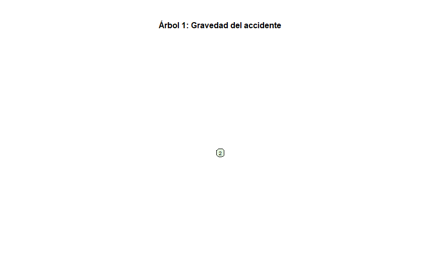

```r
# Árbol con más variables y parámetros ajustados
arbol1 <- rpart(fall_les ~
                sexo_per + tipo_eve + tipo_veh + depto_ocu + horario + mayor_menor + mes_ocu,
                data = data_arbol1,
                method = "class")

rpart.plot(arbol1, type = 2, extra = 0, under = TRUE, fallen.leaves = TRUE,
           box.palette = "BuGn", main = "Árbol 1: Gravedad del accidente", cex=0.5)
```

### El arbol no despliega ramas por lo tanto se procedió a analizar por separado los casos (fallecimientos y lesionados) ya que es más la tendencia a lesionados y la muerte ya es una situación crítica. No obstante, hubo la misma situación que el dataset no proporcionó detalles entonces se balancea para dejar casos aleatorios con el mismo numero de casos para fallecidos como lesionados.

```r
#Se crean los factores para el primer modelo
data_arbol1bal <- datos_consolidados %>%
  filter(fall_les %in% c(1, 2), sexo_per != 9, tipo_eve != 99, tipo_veh != 99, edad_per != 999)
set.seed(123)
fallecidos <- data_arbol1bal %>% filter(fall_les == 1)
lesionados <- data_arbol1bal %>% filter(fall_les == 2) %>% sample_n(nrow(fallecidos))
data_bal <- bind_rows(fallecidos, lesionados)

# Convertir variables categóricas a factor
data_bal$sexo_per <- factor(data_bal$sexo_per)
data_bal$tipo_eve <- factor(data_bal$tipo_eve)
data_bal$tipo_veh <- factor(data_bal$tipo_veh)
data_bal$depto_ocu <- factor(data_bal$depto_ocu)
data_bal$horario <- factor(data_bal$horario)
data_bal$mes_ocu <- factor(data_bal$mes_ocu)
data_bal$fall_les <- factor(data_bal$fall_les)
```

### Con el dataset balanceado entonces ya se puede verificar como quedaron distribuidos los casos para determinar el resto de las predicciones.

```r
# Calcular conteos y porcentajes por departamento
resumen <- data_bal %>%
  filter(fall_les %in% c(1, 2)) %>%
  group_by(depto_ocu, fall_les) %>%
  summarise(casos = n(), .groups = "drop") %>%
  group_by(depto_ocu) %>%
  summarise(
    Fallecido = sum(casos[fall_les == 1], na.rm = TRUE),
    Lesionado = sum(casos[fall_les == 2], na.rm = TRUE)
  ) %>%
  mutate(
    Total = Fallecido + Lesionado,
    pct_fallecido = round(Fallecido / Total * 100, 2),
    pct_lesionado = round(Lesionado / Total * 100, 2)
  ) %>%
  arrange(desc(pct_fallecido))
resumen
```

| depto_ocu | Fallecido | Lesionado | Total | pct_fallecido | pct_lesionado |
| --- | --- | --- | --- | --- | --- |
| 18 | 751 | 394 | 1145 | 65.59 | 34.41 |
| 17 | 753 | 417 | 1170 | 64.36 | 35.64 |
| 5 | 1569 | 1056 | 2625 | 59.77 | 40.23 |
| 22 | 529 | 370 | 899 | 58.84 | 41.16 |
| 20 | 384 | 287 | 671 | 57.23 | 42.77 |
| 19 | 430 | 341 | 771 | 55.77 | 44.23 |
| 8 | 137 | 111 | 248 | 55.24 | 44.76 |
| 9 | 443 | 384 | 827 | 53.57 | 46.43 |
| 6 | 523 | 461 | 984 | 53.15 | 46.85 |
| 14 | 349 | 325 | 674 | 51.78 | 48.22 |

[output cut: 12 more lines]

```r
table(data_bal$fall_les)
```

```
    1     2
12966 12966
```

## Modelo 1: Predecir gravedad (fall_les) - Dataset balanceado

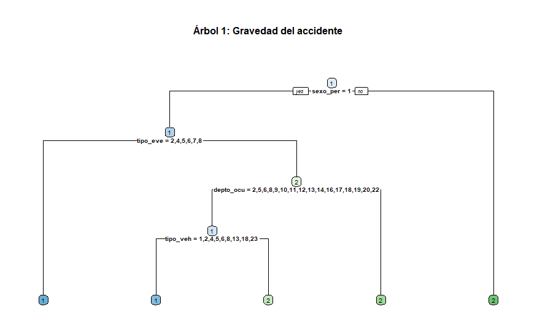

```r
# Árbol con más variables y parámetros ajustados
arbol1 <- rpart(fall_les ~ sexo_per + tipo_eve + tipo_veh + depto_ocu ,
                data = data_bal, method = "class")

rpart.plot(arbol1, type = 2, extra = 0, under = TRUE, fallen.leaves = TRUE,
           box.palette = "BuGn", main = "Árbol 1: Gravedad del accidente", cex=0.5)
```

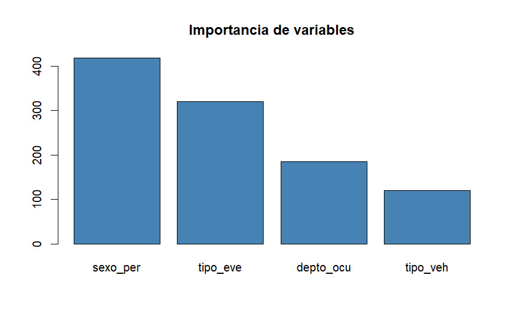

```r
barplot(arbol1$variable.importance, main="Importancia de variables", col="steelblue")
```

### Se observa que para el modelo 1 con los datos balanceados ya se aprecia que las variables predictoras que influyen son sexo, tipo de evento, departamento donde sucedio y el tipo de vehiculo.

```r
# 5 escenarios distintos
escenarios <- data.frame(
  sexo_per  = factor(c(2, 1, 2, 1, 2), levels = levels(data_bal$sexo_per)),   # Mujer/Hombre
  tipo_eve  = factor(c(2, 5, 3, 1, 6), levels = levels(data_bal$tipo_eve)),   # Choque, Atropello, Vuelco, Colisión, Derrape
  tipo_veh  = factor(c(4, 1, 3, 2, 5), levels = levels(data_bal$tipo_veh)),   # Motocicleta, Automóvil, Pick up, Camioneta sport, Camión
  depto_ocu = factor(c(1, 6, 14, 18, 22), levels = levels(data_bal$depto_ocu)) # Guatemala, Santa Rosa, Quiché, Izabal, Jutiapa
)

# Ver el dataframe
escenarios
```

| sexo_per | tipo_eve | tipo_veh | depto_ocu |
| --- | --- | --- | --- |
| 2 | 2 | 4 | 1 |
| 1 | 5 | 1 | 6 |
| 2 | 3 | 3 | 14 |
| 1 | 1 | 2 | 18 |
| 2 | 6 | 5 | 22 |

```r
NA
```

```r
## Predicciones con probabilidades para los 5 casos
predicciones <- predict(arbol1, escenarios, type = "prob")
predicciones
```

```
          1         2
1 0.3386071 0.6613929
2 0.6476476 0.3523524
3 0.3386071 0.6613929
4 0.5844703 0.4155297
5 0.3386071 0.6613929
```

## Modelo 2: Predecir tipo de evento (tipo_eve)

### Se valido que el tipo de evento más comun que desbalanceaba la clase fue el de colisión por lo tanto se excluyo ese caso para ver que tan probable es que sucedan los otros eventos.

```r
data_arbol2 <- datos_consolidados %>%
  filter(fall_les %in% c(1, 2), sexo_per != 9, tipo_eve != 99,tipo_eve!=1, tipo_veh != 99, edad_per != 999)
data_arbol2$tipo_veh <- factor(data_arbol2$tipo_veh)
data_arbol2$depto_ocu <- factor(data_arbol2$depto_ocu)
data_arbol2$horario <- factor(data_arbol2$horario)
data_arbol2$fall_les <- factor(data_arbol2$fall_les)
data_arbol2$mayor_menor <- factor(data_arbol2$mayor_menor)
data_arbol2$sexo_per <- factor(data_arbol2$sexo_per)
table(data_arbol1$tipo_eve)
```

```
    1     2     3     4     5     6     7     8
41740  7650  6131  2562 16531  4092   979    18
```

```r
table(data_arbol2$tipo_eve)
```

```
    2     3     4     5     6     7     8
 7650  6131  2562 16531  4092   979    18
```

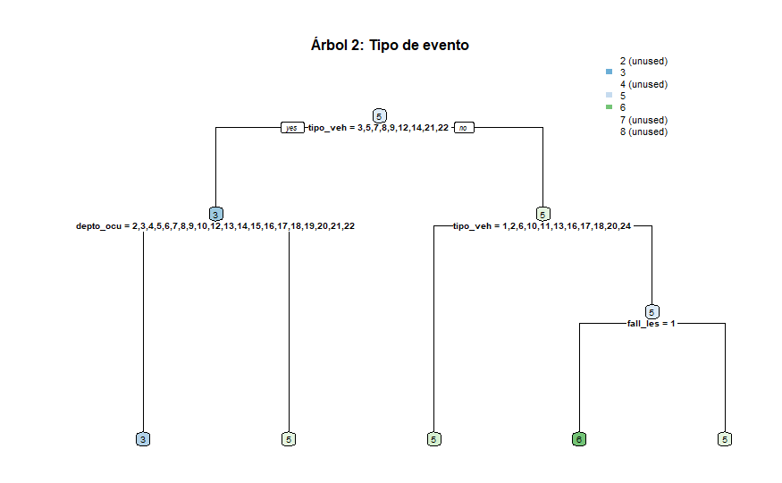

```r
arbol2 <- rpart(tipo_eve ~  tipo_veh +depto_ocu + fall_les + mayor_menor + horario + sexo_per,
                data = data_arbol2, method = "class")
rpart.plot(arbol2,type=2,extra=0, under=TRUE,fallen.leaves = TRUE,box.palette = "BuGn", main = "Árbol 2: Tipo de evento", cex=0.5)
```

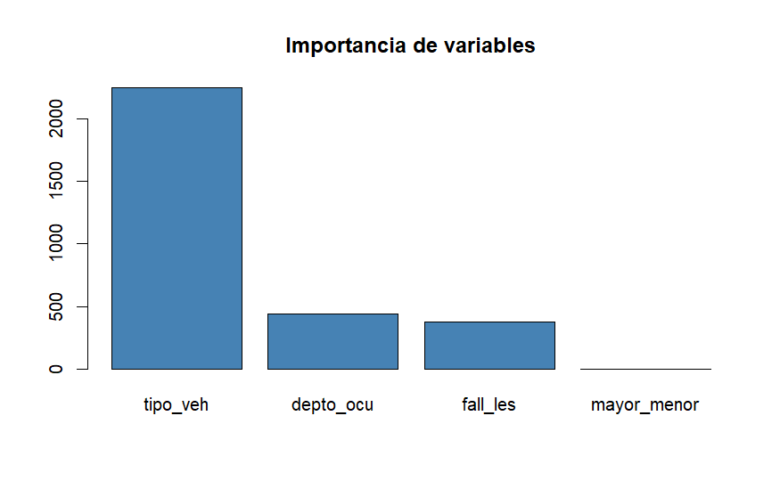

```r
barplot(arbol2$variable.importance, main="Importancia de variables", col="steelblue")
```

```r
# 5 escenarios distintos
escenarios <- data.frame(
  sexo_per  = factor(c(2, 1, 2, 1, 2), levels = levels(data_arbol2$sexo_per)),   # Mujer/Hombre
  horario  = factor(c(1, 2, 1, 1, 2), levels = levels(data_arbol2$horario)),   # Día, Noche
  mayor_menor  = factor(c(1, 2, 2, 1, 1), levels = levels(data_arbol2$mayor_menor)),   # Mayor,Menor
  tipo_veh  = factor(c(4, 1, 3, 2, 5), levels = levels(data_arbol2$tipo_veh)),   # Motocicleta, Automóvil, Pick up, Camioneta sport, Camión
  depto_ocu = factor(c(1, 6, 14, 18, 22), levels = levels(data_arbol2$depto_ocu)), # Guatemala, Santa Rosa, Quiché, Izabal, Jutiapa
  fall_les = factor(c(1, 1, 2, 2, 2), levels = levels(data_arbol2$fall_les)) # Guatemala, Santa Rosa, Quiché, Izabal, Jutiapa
)

# Ver el dataframe
escenarios
```

| sexo_per | horario | mayor_menor | tipo_veh | depto_ocu | fall_les |
| --- | --- | --- | --- | --- | --- |
| 2 | 1 | 1 | 4 | 1 | 1 |
| 1 | 2 | 2 | 1 | 6 | 1 |
| 2 | 1 | 2 | 3 | 14 | 2 |
| 1 | 1 | 1 | 2 | 18 | 2 |
| 2 | 2 | 1 | 5 | 22 | 2 |

```r
NA
```

```r
## Predicciones con probabilidades para los 5 casos
predicciones <- predict(arbol2, escenarios, type = "prob")
predicciones
```

```
          2          3          4         5           6           7            8
1 0.3185361 0.01660454 0.08268384 0.1755337 0.401219925 0.004744155 0.0006777364
2 0.2018901 0.09502544 0.02222453 0.6528196 0.008412088 0.018797383 0.0008308236
3 0.2126374 0.37140220 0.10346564 0.2402450 0.012167492 0.059830494 0.0002517412
4 0.2018901 0.09502544 0.02222453 0.6528196 0.008412088 0.018797383 0.0008308236
5 0.2126374 0.37140220 0.10346564 0.2402450 0.012167492 0.059830494 0.0002517412
```

## Modelo 3: Predcir tipo de vehiculo

### Se excluyen los casos en motocicletas porque estos son los que predominan y desbalancean el dataset.

```r
data_arbol3 <- datos_consolidados %>%
  filter(fall_les %in% c(1, 2), sexo_per != 9, tipo_eve != 99, tipo_veh != 99,tipo_veh != 4, edad_per != 999)
data_arbol3$sexo_per <- factor(data_arbol3$sexo_per)
data_arbol3$tipo_eve <- factor(data_arbol3$tipo_eve)
data_arbol3$tipo_veh <- factor(data_arbol3$tipo_veh)
data_arbol3$depto_ocu <- factor(data_arbol3$depto_ocu)
data_arbol3$zona_ocu <- factor(data_arbol3$zona_ocu)
data_arbol3$fall_les <- factor(data_arbol3$fall_les)
data_arbol3$horario <- factor(data_arbol3$horario)
data_arbol3$mayor_menor <- factor(data_arbol3$mayor_menor)
table(data_arbol3$tipo_veh)
```

```
    1     2     3     5     6     7     8     9    10    11    12    13    14    16    17    18    20    21    22
11192  3847 10197  2817   909  1033    94  3493    89   425  4356    40  1474    10    42   221     2    15   237
   23    24
    2     1
```

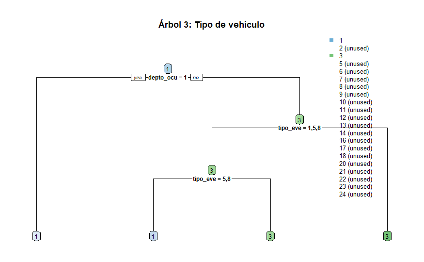

```r
# Árbol para tipo de vehículo
arbol3 <- rpart(tipo_veh ~ tipo_eve + sexo_per + depto_ocu + horario + fall_les + mayor_menor,
                data = data_arbol3, method = "class")


rpart.plot(arbol3, type = 2, extra = 0, under = TRUE, fallen.leaves = TRUE,
           box.palette = "BuGn", main = "Árbol 3: Tipo de vehículo", cex = 0.6)
```

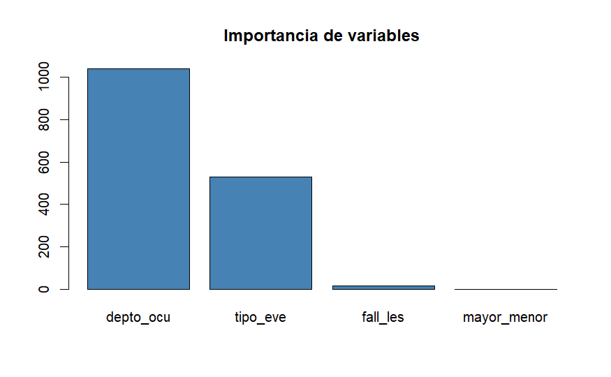

```r
barplot(arbol3$variable.importance, main="Importancia de variables", col="steelblue")
```

```r
# 5 escenarios distintos
escenarios <- data.frame(
  sexo_per  = factor(c(2, 1, 2, 1, 2), levels = levels(data_arbol3$sexo_per)),   # Mujer/Hombre
  horario  = factor(c(1, 2, 1, 1, 2), levels = levels(data_arbol3$horario)),   # Día, Noche
  mayor_menor  = factor(c(1, 2, 2, 1, 1), levels = levels(data_arbol3$mayor_menor)),   # Mayor,Menor
  tipo_eve  = factor(c(2, 5, 3, 1, 6), levels = levels(data_arbol3$tipo_eve)), # Choque, Atropello, Vuelco, Colisión, Derrape

  depto_ocu = factor(c(1, 6, 14, 18, 22), levels = levels(data_arbol3$depto_ocu)), # Guatemala, Santa Rosa, Quiché, Izabal, Jutiapa
  fall_les = factor(c(1, 1, 2, 2, 2), levels = levels(data_arbol3$fall_les)) # Guatemala, Santa Rosa, Quiché, Izabal, Jutiapa
)

# Ver el dataframe
escenarios
```

| sexo_per | horario | mayor_menor | tipo_eve | depto_ocu | fall_les |
| --- | --- | --- | --- | --- | --- |
| 2 | 1 | 1 | 2 | 1 | 1 |
| 1 | 2 | 2 | 5 | 6 | 1 |
| 2 | 1 | 2 | 3 | 14 | 2 |
| 1 | 1 | 1 | 1 | 18 | 2 |
| 2 | 2 | 1 | 6 | 22 | 2 |

```r
NA
```

```r
# Predicción con probabilidades
result <- predict(arbol3, escenarios, type = "prob")
result
```

```
           1          2         3          5          6           7            8          9           10
1 0.50624760 0.09246444 0.1186082 0.04392541 0.01835832 0.015667051 0.0006728181 0.04181084 0.0056708958
2 0.36360754 0.09716278 0.2444127 0.09605326 0.04311301 0.008876209 0.0017435410 0.04121097 0.0023775559
3 0.09674882 0.07830799 0.3574550 0.09211676 0.01538193 0.045184408 0.0023597273 0.09211676 0.0007865758
4 0.20452151 0.11149826 0.2699133 0.05672150 0.02187829 0.024066121 0.0039705048 0.14131756 0.0004861843
5 0.09674882 0.07830799 0.3574550 0.09211676 0.01538193 0.045184408 0.0023597273 0.09211676 0.0007865758
           11         12           13         14           16          17           18           20         21
1 0.013456363 0.10640138 0.0002883506 0.02383699 0.0002883506 0.004036909 0.0055747789 0.000000e+00 0.00000000
2 0.009351720 0.04295451 0.0025360596 0.03487082 0.0001585037 0.000000000 0.0057061341 1.585037e-04 0.00000000
3 0.006554798 0.17811571 0.0010487677 0.02683097 0.0000000000 0.000000000 0.0005243838 8.739731e-05 0.00131096
4 0.012235637 0.07616887 0.0007292764 0.05664047 0.0004861843 0.000000000 0.0098047160 0.000000e+00 0.00000000
5 0.006554798 0.17811571 0.0010487677 0.02683097 0.0000000000 0.000000000 0.0005243838 8.739731e-05 0.00131096
           22           23           24
1 0.002691273 0.0000000000 0.0000000000
2 0.005547630 0.0000000000 0.0001585037
3 0.005069044 0.0000000000 0.0000000000
4 0.009399562 0.0001620614 0.0000000000
5 0.005069044 0.0000000000 0.0000000000
```

## Modelo 4: Predecir horario (día/noche)

### En esta predicción si se formo bien el arbol sin necesidad de filtrar ya que sia habia buena distribución en el dataset.

```r
data_arbol4 <- datos_consolidados %>%
  filter(fall_les %in% c(1, 2), sexo_per != 9, tipo_eve != 99, tipo_veh != 99, edad_per != 999)
data_arbol4$sexo_per <- factor(data_arbol4$sexo_per)
data_arbol4$tipo_eve <- factor(data_arbol4$tipo_eve)
data_arbol4$tipo_veh <- factor(data_arbol4$tipo_veh)
data_arbol4$depto_ocu <- factor(data_arbol4$depto_ocu)
data_arbol4$zona_ocu <- factor(data_arbol4$zona_ocu)
data_arbol4$fall_les <- factor(data_arbol4$fall_les)
data_arbol4$horario <- factor(data_arbol4$horario)
data_arbol4$mayor_menor <- factor(data_arbol4$mayor_menor)
table(data_arbol4$horario)
```

```
    1     2
46025 33678
```

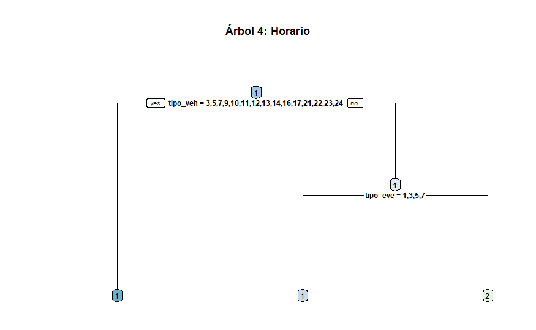

```r
arbol4 <- rpart(horario ~  tipo_eve +sexo_per + tipo_veh + depto_ocu + fall_les + mayor_menor, data = data_arbol4, method = "class")

rpart.plot(arbol4, type = 2, extra = 0, under = TRUE, fallen.leaves = TRUE,
           box.palette = "BuGn", main = "Árbol 4: Horario", cex = 0.6)
```

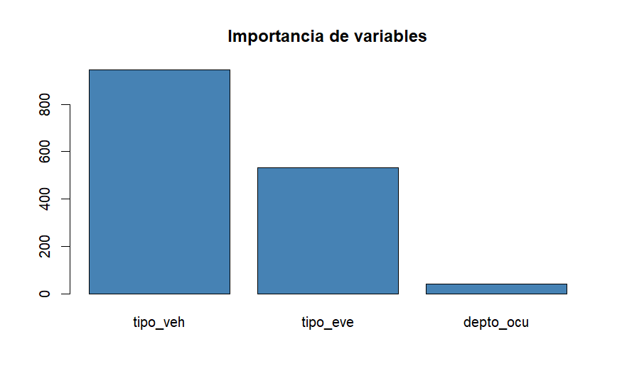

```r
barplot(arbol4$variable.importance, main="Importancia de variables", col="steelblue")
```

```r
# 5 escenarios distintos
escenarios <- data.frame(
  sexo_per  = factor(c(2, 1, 2, 1, 2), levels = levels(data_arbol4$sexo_per)),   # Mujer/Hombre
  mayor_menor  = factor(c(1, 2, 2, 1, 1), levels = levels(data_arbol4$mayor_menor)),   # Mayor,Menor
  tipo_eve  = factor(c(2, 5, 3, 1, 6), levels = levels(data_arbol4$tipo_eve)), # Choque, Atropello, Vuelco, Colisión, Derrape
  tipo_veh  = factor(c(4, 1, 3, 2, 5), levels = levels(data_arbol4$tipo_veh)),   # Motocicleta, Automóvil, Pick up, Camioneta sport, Camión
  depto_ocu = factor(c(1, 6, 14, 18, 22), levels = levels(data_arbol4$depto_ocu)), # Guatemala, Santa Rosa, Quiché, Izabal, Jutiapa
  fall_les = factor(c(1, 1, 2, 2, 2), levels = levels(data_arbol4$fall_les)) # Fallecido, Lesionado
)

# Ver el dataframe
escenarios
```

| sexo_per | mayor_menor | tipo_eve | tipo_veh | depto_ocu | fall_les |
| --- | --- | --- | --- | --- | --- |
| 2 | 1 | 2 | 4 | 1 | 1 |
| 1 | 2 | 5 | 1 | 6 | 1 |
| 2 | 2 | 3 | 3 | 14 | 2 |
| 1 | 1 | 1 | 2 | 18 | 2 |
| 2 | 1 | 6 | 5 | 22 | 2 |

```r
NA
```

```r
# Predicción con probabilidades
result <- predict(arbol4, escenarios, type = "prob")
result
```

```
          1         2
1 0.4034543 0.5965457
2 0.5525402 0.4474598
3 0.6939870 0.3060130
4 0.5525402 0.4474598
5 0.6939870 0.3060130
```

## Modelo 5: Predecir depto ocurrencia

### En esta predicción si se formo bien el arbol pero filtrando el interior del pais. Se excluyó Guatemala.

```r
data_arbol5 <- datos_consolidados %>%
  filter(fall_les %in% c(1, 2), sexo_per != 9, tipo_eve != 99,depto_ocu!=1, tipo_veh != 99, edad_per != 999)
data_arbol5$sexo_per <- factor(data_arbol5$sexo_per)
data_arbol5$tipo_eve <- factor(data_arbol5$tipo_eve)
data_arbol5$tipo_veh <- factor(data_arbol5$tipo_veh)
data_arbol5$depto_ocu <- factor(data_arbol5$depto_ocu)
data_arbol5$zona_ocu <- factor(data_arbol5$zona_ocu)
data_arbol5$fall_les <- factor(data_arbol5$fall_les)
data_arbol5$horario <- factor(data_arbol5$horario)
data_arbol5$mayor_menor <- factor(data_arbol5$mayor_menor)
table(data_arbol5$depto_ocu)
```

```
   2    3    4    5    6    7    8    9   10   11   12   13   14   15   16   17   18   19   20   21   22
2081 2769 3120 6855 2956 1502  750 2500 2651 2191 1888 1771 2149 1732 4302 2804 2716 2152 1839 1364 2464
```

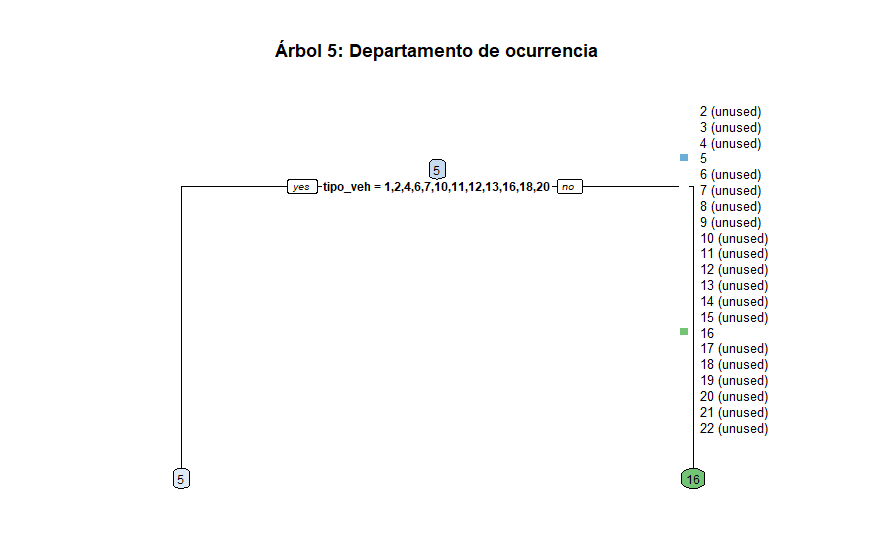

```r
arbol5 <- rpart(depto_ocu ~  tipo_eve +sexo_per + tipo_veh + fall_les + mayor_menor, data = data_arbol5, method = "class")

rpart.plot(arbol5, type = 2, extra = 0, under = TRUE, fallen.leaves = TRUE,
           box.palette = "BuGn", main = "Árbol 5: Departamento de ocurrencia", cex = 0.6)
```

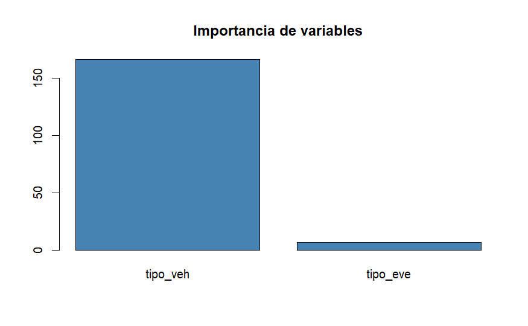

```r
barplot(arbol5$variable.importance, main="Importancia de variables", col="steelblue")
```

```r
# 5 escenarios distintos
escenarios <- data.frame(
  sexo_per  = factor(c(2, 1, 2, 1, 2), levels = levels(data_arbol5$sexo_per)),   # Mujer/Hombre
  mayor_menor  = factor(c(1, 2, 2, 1, 1), levels = levels(data_arbol5$mayor_menor)),   # Mayor,Menor
  tipo_eve  = factor(c(2, 5, 3, 1, 6), levels = levels(data_arbol5$tipo_eve)), # Choque, Atropello, Vuelco, Colisión, Derrape
  tipo_veh  = factor(c(4, 1, 3, 2, 5), levels = levels(data_arbol5$tipo_veh)),   # Motocicleta, Automóvil, Pick up, Camioneta sport, Camión

  fall_les = factor(c(1, 1, 2, 2, 2), levels = levels(data_arbol5$depto_ocu)) # Fallecido, Lesionado
)

# Ver el dataframe
escenarios
```

| sexo_per | mayor_menor | tipo_eve | tipo_veh | fall_les |
| --- | --- | --- | --- | --- |
| 2 | 1 | 2 | 4 | NA |
| 1 | 2 | 5 | 1 | NA |
| 2 | 2 | 3 | 3 | 2 |
| 1 | 1 | 1 | 2 | 2 |
| 2 | 1 | 6 | 5 | 2 |

```r
# Predicción con probabilidades
result <- predict(arbol5, escenarios, type = "prob")
result
```

```
           2          3          4          5          6          7          8          9         10         11
1 0.03649515 0.06117101 0.06078886 0.15788181 0.05773168 0.02372049 0.01130067 0.04864201 0.05246349 0.04623993
2 0.03649515 0.06117101 0.06078886 0.15788181 0.05773168 0.02372049 0.01130067 0.04864201 0.05246349 0.04623993
3 0.04673073 0.03316375 0.05608944 0.06726964 0.05282332 0.03975881 0.02110420 0.04509767 0.04578858 0.03121663
4 0.03649515 0.06117101 0.06078886 0.15788181 0.05773168 0.02372049 0.01130067 0.04864201 0.05246349 0.04623993
5 0.04673073 0.03316375 0.05608944 0.06726964 0.05282332 0.03975881 0.02110420 0.04509767 0.04578858 0.03121663
          12         13         14         15        16         17         18         19        20         21
1 0.03390201 0.02811519 0.02789682 0.03106319 0.0664392 0.05360994 0.05623038 0.04236386 0.0332196 0.02382967
2 0.03390201 0.02811519 0.02789682 0.03106319 0.0664392 0.05360994 0.05623038 0.04236386 0.0332196 0.02382967
3 0.04057534 0.04654230 0.07078701 0.03730921 0.1173293 0.05276050 0.04120344 0.03768607 0.0390679 0.03083977
4 0.03390201 0.02811519 0.02789682 0.03106319 0.0664392 0.05360994 0.05623038 0.04236386 0.0332196 0.02382967
5 0.04057534 0.04654230 0.07078701 0.03730921 0.1173293 0.05276050 0.04120344 0.03768607 0.0390679 0.03083977
          22
1 0.04689505
2 0.04689505
3 0.04685635
4 0.04689505
5 0.04685635
```

```r
table(data_arbol1$mes_ocu)
```

```
   1    2    3    4    5    6    7    8    9   10   11   12
6780 6518 7218 6976 6504 5636 6435 6149 6317 6351 6832 7987
```

# BOSQUES ALEATORIOS

```r
library(randomForest)
```

## MODELO 1: PREDECIR CONSECUENCIA (FALL/LES) - SIN BALANCEAR

```r
data_rf1 <- datos_consolidados %>%
  filter(fall_les %in% c(1, 2), sexo_per != 9, tipo_eve != 99, tipo_veh != 99, edad_per != 999)

data_rf1$sexo_per <- factor(data_rf1$sexo_per)
data_rf1$tipo_eve <- factor(data_rf1$tipo_eve)
data_rf1$tipo_veh <- factor(data_rf1$tipo_veh)
data_rf1$depto_ocu <- factor(data_rf1$depto_ocu)
data_rf1$horario <- factor(data_rf1$horario)
data_rf1$fall_les <- factor(data_rf1$fall_les)

set.seed(123)

data <-  data_rf1[sample(1:nrow(data_rf1)), ]
train_index <- sample(1:nrow(data), 0.7 * nrow(data))
train_data <- data[train_index, ]
test_data <- data[-train_index, ]

modelo_rf1 <- randomForest(fall_les ~ sexo_per + tipo_eve + tipo_veh + depto_ocu,
                           data = train_data, ntree = 100, mtry = 4, importance = TRUE)

modelo_rf1
```

```
Call:
 randomForest(formula = fall_les ~ sexo_per + tipo_eve + tipo_veh +      depto_ocu, data = train_data, ntree = 100, mtry = 4, importance = TRUE)
               Type of random forest: classification
                     Number of trees: 100
No. of variables tried at each split: 4

        OOB estimate of  error rate: 16.85%
Confusion matrix:
     1     2 class.error
1  791  8332  0.91329606
2 1071 45598  0.02294885
```

### A diferencia del modelo de arboles de decisión, en el caso de bosques aleatorios si obtuvimos un resultado con un OOB del 16.85%.

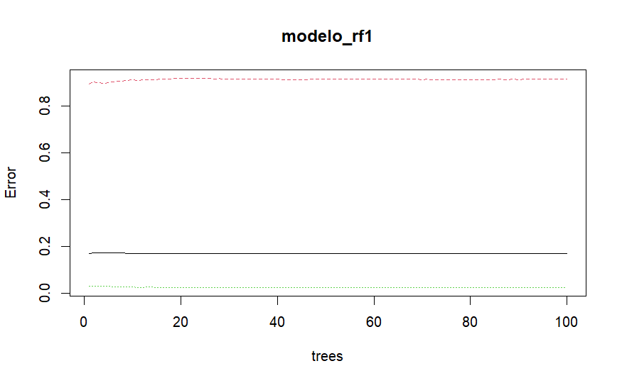

```r
plot(modelo_rf1)
```

```r
predictions <- predict(modelo_rf1, newdata = test_data)
conf_matrix <- table(test_data$fall_les, predictions)
conf_matrix
```

```
   predictions
        1     2
  1   378  3465
  2   472 19596
```

```r
accuracy <- sum(diag(conf_matrix)) / sum(conf_matrix)
accuracy
```

```
[1] 0.8353477
```

### Tenemos un accuracy del 83% en el testeo.

```r
escenarios <- data.frame(
  sexo_per  = factor(c(2, 1, 2, 1, 2), levels = levels(data_rf1$sexo_per)),
  tipo_eve  = factor(c(2, 5, 3, 1, 6), levels = levels(data_rf1$tipo_eve)),
  tipo_veh  = factor(c(4, 1, 3, 2, 5), levels = levels(data_rf1$tipo_veh)),
  depto_ocu = factor(c(1, 6, 14, 18, 22), levels = levels(data_rf1$depto_ocu)))

pred_rf1 <- predict(modelo_rf1, escenarios, type = "prob")
pred_rf1
```

```
     1    2
1 0.00 1.00
2 0.01 0.99
3 0.00 1.00
4 0.01 0.99
5 0.19 0.81
attr(,"class")
[1] "matrix" "array"  "votes"
```

#### En este modelo no tenemos contra que comparar pero para propositos de evaluar las diferencias con el dataset balanceado vemos el siguiente bosque.

## MODELO 1: PREDECIR CONSECUENCIA (FALL/ LES) - BALANCEADO

```r
data_rf1b <- datos_consolidados %>%
  filter(fall_les %in% c(1, 2), sexo_per != 9, tipo_eve != 99, tipo_veh != 99, edad_per != 999)
data_bal <- data_rf1b
set.seed(123)
fallecidos <- data_rf1b %>% filter(fall_les == 1)
lesionados <- data_rf1b %>% filter(fall_les == 2) %>% sample_n(nrow(fallecidos))
data_bal <- bind_rows(fallecidos, lesionados)

# Convertir variables categóricas a factor
data_bal$sexo_per <- factor(data_bal$sexo_per)
data_bal$tipo_eve <- factor(data_bal$tipo_eve)
data_bal$tipo_veh <- factor(data_bal$tipo_veh)
data_bal$depto_ocu <- factor(data_bal$depto_ocu)
data_bal$horario <- factor(data_bal$horario)
data_bal$fall_les <- factor(data_bal$fall_les)

set.seed(123)

data <-  data_bal[sample(1:nrow(data_bal)), ]
train_index <- sample(1:nrow(data), 0.7 * nrow(data))
train_data <- data[train_index, ]
test_data <- data[-train_index, ]

modelo_rf1b <- randomForest(fall_les ~ sexo_per + tipo_eve + tipo_veh + depto_ocu,
                           data = train_data, ntree = 100, mtry = 4, importance = TRUE)

modelo_rf1b
```

```
Call:
 randomForest(formula = fall_les ~ sexo_per + tipo_eve + tipo_veh +      depto_ocu, data = train_data, ntree = 100, mtry = 4, importance = TRUE)
               Type of random forest: classification
                     Number of trees: 100
No. of variables tried at each split: 4

        OOB estimate of  error rate: 35.21%
Confusion matrix:
     1    2 class.error
1 6283 2781   0.3068182
2 3611 5477   0.3973371
```

### Se obtuvo un OBB del 35% para este caso donde habia balanceo en los registros.

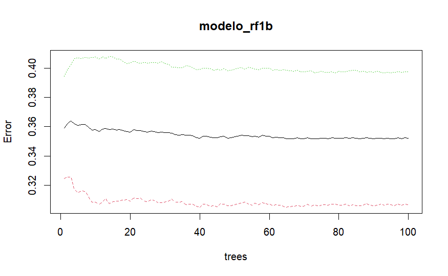

```r
plot(modelo_rf1b)
```

```r
predictions <- predict(modelo_rf1b, newdata = test_data)
conf_matrix <- table(test_data$fall_les, predictions)
conf_matrix
```

```
   predictions
       1    2
  1 2721 1181
  2 1598 2280
```

```r
accuracy <- sum(diag(conf_matrix)) / sum(conf_matrix)
accuracy
```

```
[1] 0.6428021
```

```r
escenarios <- data.frame(
  sexo_per  = factor(c(2, 1, 2, 1, 2), levels = levels(data_bal$sexo_per)),
  tipo_eve  = factor(c(2, 5, 3, 1, 6), levels = levels(data_bal$tipo_eve)),
  tipo_veh  = factor(c(4, 1, 3, 2, 5), levels = levels(data_bal$tipo_veh)),
  depto_ocu = factor(c(1, 6, 14, 18, 22), levels = levels(data_bal$depto_ocu)))

pred_rf1b <- predict(modelo_rf1b, escenarios, type = "prob")
pred_rf1b
```

```
     1    2
1 0.23 0.77
2 1.00 0.00
3 0.07 0.93
4 0.84 0.16
5 0.59 0.41
attr(,"class")
[1] "matrix" "array"  "votes"
```

### MODELO 2: PREDECIR TIPO DE EVENTO - Excluyendo colisiones

```r
# Preparar datos y factores
data_arbol2$tipo_eve   <- factor(data_arbol2$tipo_eve)
data_arbol2$tipo_veh   <- factor(data_arbol2$tipo_veh)
data_arbol2$depto_ocu  <- factor(data_arbol2$depto_ocu)
data_arbol2$horario    <- factor(data_arbol2$horario)
data_arbol2$fall_les   <- factor(data_arbol2$fall_les)
data_arbol2$sexo_per   <- factor(data_arbol2$sexo_per)
data_arbol2$mayor_menor   <- factor(data_arbol2$mayor_menor)

# Entrenar RF
set.seed(123)
data <-  data_arbol2[sample(1:nrow(data_arbol2)), ]
train_index <- sample(1:nrow(data), 0.7 * nrow(data))
train_data <- data[train_index, ]
test_data <- data[-train_index, ]
modelo_rf2 <- randomForest(tipo_eve ~ tipo_veh + depto_ocu + fall_les + mayor_menor + horario + sexo_per,
                           data = train_data, ntree = 50, mtry = 3, importance = TRUE)


modelo_rf2
```

```
Call:
 randomForest(formula = tipo_eve ~ tipo_veh + depto_ocu + fall_les +      mayor_menor + horario + sexo_per, data = train_data, ntree = 50,      mtry = 3, importance = TRUE)
               Type of random forest: classification
                     Number of trees: 50
No. of variables tried at each split: 3

        OOB estimate of  error rate: 46.75%
Confusion matrix:
    2    3   4    5    6  7 8 class.error
2 854  888  63 2613  934 25 0   0.8411754
3 432 2411  99 1192   56 24 0   0.4278595
4 133  436 190  715  269 32 0   0.8929577
5 542  923  79 9280  748 35 0   0.2004825
6  88   48   6 1399 1345  0 0   0.5339570
7  74  290  21  238    8 71 0   0.8988604
8   2    1   0    8    2  0 0   1.0000000
```

# Se obtuvo muy alto error pero se hara la prediccion para comparar resultados.

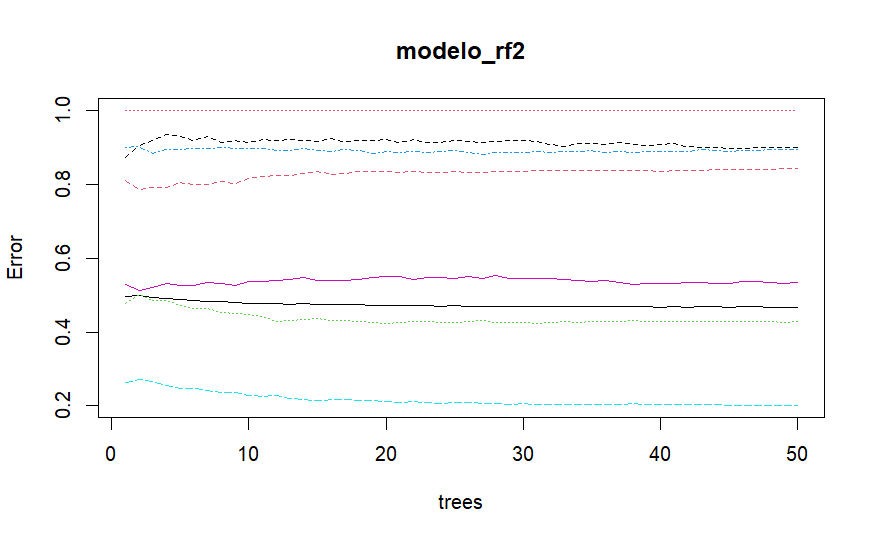

```r
plot(modelo_rf2)
```

```r
predictions <- predict(modelo_rf2, newdata = test_data)
conf_matrix <- table(test_data$tipo_eve, predictions)
conf_matrix
```

```
   predictions
       2    3    4    5    6    7    8
  2  373  378   32 1106  379    5    0
  3  224 1085   34  534   26   14    0
  4   68  189   94  313  108   15    0
  5  221  372   40 3992  289   10    0
  6   38   30    1  601  536    0    0
  7   29  122   18   81    6   21    0
  8    0    1    0    2    2    0    0
```

```r
accuracy <- sum(diag(conf_matrix)) / sum(conf_matrix)
accuracy
```

```
[1] 0.5356923
```

```r
escenarios <- data.frame(
  sexo_per  = factor(c(2, 1, 2, 1, 2), levels = levels(data_arbol2$sexo_per)),   # Mujer/Hombre
  horario  = factor(c(1, 2, 1, 1, 2), levels = levels(data_arbol2$horario)),   # Día, Noche
  mayor_menor  = factor(c(1, 2, 2, 1, 1), levels = levels(data_arbol2$mayor_menor)),   # Mayor,Menor
  tipo_veh  = factor(c(4, 1, 3, 2, 5), levels = levels(data_arbol2$tipo_veh)),   # Motocicleta, Automóvil, Pick up, Camioneta sport, Camión
  depto_ocu = factor(c(1, 6, 14, 18, 22), levels = levels(data_arbol2$depto_ocu)), # Guatemala, Santa Rosa, Quiché, Izabal, Jutiapa
  fall_les = factor(c(1, 1, 2, 2, 2), levels = levels(data_arbol2$fall_les)) # Guatemala, Santa Rosa, Quiché, Izabal, Jutiapa
)
pred_rf2 <- predict(modelo_rf2, escenarios, type = "prob")
pred_rf2
```

```
     2    3    4    5    6 7 8
1 0.00 0.00 0.00 0.94 0.06 0 0
2 0.08 0.28 0.02 0.62 0.00 0 0
3 0.12 0.84 0.04 0.00 0.00 0 0
4 0.62 0.12 0.00 0.26 0.00 0 0
5 0.08 0.74 0.06 0.12 0.00 0 0
attr(,"class")
[1] "matrix" "array"  "votes"
```

### MODELO 2: PREDECIR TIPO DE EVENTO - Incluyendo todos los eventos

```r
data_rf2todos <- datos_consolidados %>%
  filter(fall_les %in% c(1, 2), sexo_per != 9, tipo_eve != 99, tipo_veh != 99, edad_per != 999)

data_rf2todos$tipo_eve   <- factor(data_rf2todos$tipo_eve)
data_rf2todos$tipo_veh   <- factor(data_rf2todos$tipo_veh)
data_rf2todos$depto_ocu  <- factor(data_rf2todos$depto_ocu)
data_rf2todos$horario    <- factor(data_rf2todos$horario)
data_rf2todos$fall_les   <- factor(data_rf2todos$fall_les)
data_rf2todos$sexo_per   <- factor(data_rf2todos$sexo_per)
data_rf2todos$mayor_menor   <- factor(data_rf2todos$mayor_menor)

# Entrenar RF
set.seed(123)
data <-  data_rf2todos[sample(1:nrow(data_rf2todos)), ]
train_index <- sample(1:nrow(data), 0.7 * nrow(data))
train_data <- data[train_index, ]
test_data <- data[-train_index, ]
modelo_rf2todos <- randomForest(tipo_eve ~ tipo_veh + depto_ocu + fall_les + mayor_menor + horario + sexo_per ,
                           data = train_data, ntree = 50, mtry = 3, importance = TRUE)


modelo_rf2todos
```

```
Call:
 randomForest(formula = tipo_eve ~ tipo_veh + depto_ocu + fall_les +      mayor_menor + horario + sexo_per, data = train_data, ntree = 50,      mtry = 3, importance = TRUE)
               Type of random forest: classification
                     Number of trees: 50
No. of variables tried at each split: 3

        OOB estimate of  error rate: 43.16%
Confusion matrix:
      1   2    3   4    5 6  7 8 class.error
1 25846 167  896  30 2274 0 18 0   0.1158017
2  3712 261  513  25  870 1 10 0   0.9515950
3  2048 121 1587  43  511 0 17 0   0.6332332
4  1190  36  281 126  168 0  9 0   0.9303867
5  7116 116  426  25 3860 1 10 0   0.6659166
6  2676   8   35   0   63 1  0 0   0.9996407
7   305  21  194  16  116 0 30 0   0.9560117
8    12   0    1   0    0 0  0 0   1.0000000
```

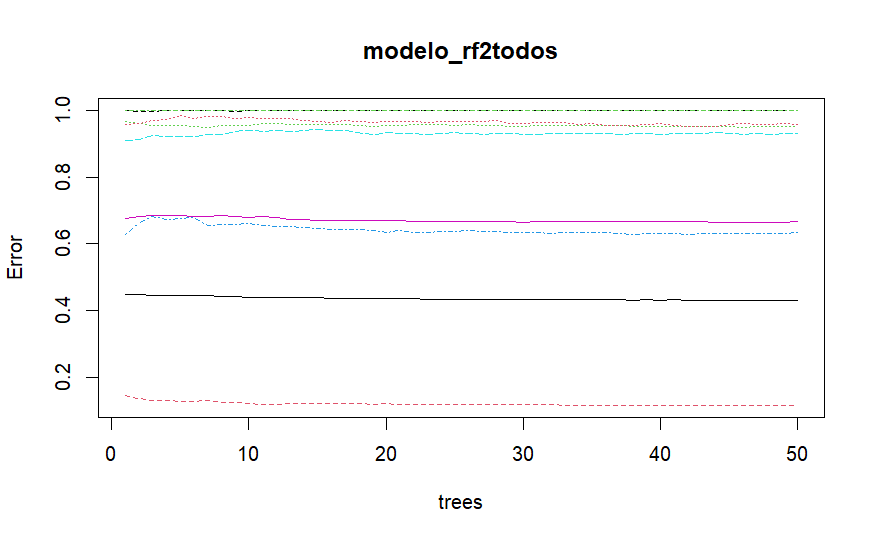

```r
plot(modelo_rf2todos)
```

```r
predictions <- predict(modelo_rf2todos, newdata = test_data)
conf_matrix <- table(test_data$tipo_eve, predictions)
conf_matrix
```

```
   predictions
        1     2     3     4     5     6     7     8
  1 10971    82   389    12  1047     0     8     0
  2  1552   112   192    19   379     0     4     0
  3   826    59   670    22   216     1    10     0
  4   494    21   111    60    60     0     6     0
  5  3136    64   176    12  1585     0     4     0
  6  1264     7    15     1    22     0     0     0
  7   135    15    80     8    47     0    12     0
  8     3     1     1     0     0     0     0     0
```

```r
accuracy <- sum(diag(conf_matrix)) / sum(conf_matrix)
accuracy
```

```
[1] 0.5608297
```

```r
escenarios <- data.frame(
  sexo_per  = factor(c(2, 1, 2, 1, 2), levels = levels(data_rf2todos$sexo_per)),   # Mujer/Hombre
  horario  = factor(c(1, 2, 1, 1, 2), levels = levels(data_rf2todos$horario)),   # Día, Noche
  mayor_menor  = factor(c(1, 2, 2, 1, 1), levels = levels(data_rf2todos$mayor_menor)),   # Mayor,Menor
  tipo_veh  = factor(c(4, 1, 3, 2, 5), levels = levels(data_rf2todos$tipo_veh)),   # Motocicleta, Automóvil, Pick up, Camioneta sport, Camión
  depto_ocu = factor(c(1, 6, 14, 18, 22), levels = levels(data_rf2todos$depto_ocu)), # Guatemala, Santa Rosa, Quiché, Izabal, Jutiapa
  fall_les = factor(c(1, 1, 2, 2, 2), levels = levels(data_rf2todos$fall_les)) # Guatemala, Santa Rosa, Quiché, Izabal, Jutiapa
)
pred_rf2 <- predict(modelo_rf2todos, escenarios, type = "prob")
pred_rf2
```

```
     1    2    3 4    5    6 7 8
1 0.94 0.00 0.00 0 0.06 0.00 0 0
2 0.22 0.06 0.10 0 0.58 0.04 0 0
3 0.06 0.02 0.92 0 0.00 0.00 0 0
4 0.86 0.02 0.02 0 0.10 0.00 0 0
5 0.48 0.04 0.38 0 0.10 0.00 0 0
attr(,"class")
[1] "matrix" "array"  "votes"
```

### MODELO 3: PREDICCION DE TIPO DE VEHICULO

```r
# Preparar datos y factores
data_arbol3$tipo_veh   <- factor(data_arbol3$tipo_veh)
data_arbol3$tipo_eve   <- factor(data_arbol3$tipo_eve)
data_arbol3$sexo_per   <- factor(data_arbol3$sexo_per)
data_arbol3$depto_ocu  <- factor(data_arbol3$depto_ocu)
data_arbol3$horario    <- factor(data_arbol3$horario)
data_arbol3$fall_les   <- factor(data_arbol3$fall_les)
data_arbol3$mayor_menor   <- factor(data_arbol3$mayor_menor)

# Entrenar RF
set.seed(123)

data <-  data_arbol3[sample(1:nrow(data_arbol3)), ]
train_index <- sample(1:nrow(data), 0.7 * nrow(data))
train_data <- data[train_index, ]
test_data <- data[-train_index, ]

modelo_rf3 <- randomForest(tipo_veh ~ tipo_eve + sexo_per + depto_ocu + horario + fall_les + mayor_menor,
                           data = train_data, ntree = 100, mtry = 4, importance = TRUE)
modelo_rf3
```

```
Call:
 randomForest(formula = tipo_veh ~ tipo_eve + sexo_per + depto_ocu +      horario + fall_les + mayor_menor, data = train_data, ntree = 100,      mtry = 4, importance = TRUE)
               Type of random forest: classification
                     Number of trees: 100
No. of variables tried at each split: 4

        OOB estimate of  error rate: 59.93%
Confusion matrix:
      1   2    3   5  6  7 8   9 10 11   12 13 14 16 17 18 20 21 22 23 24 class.error
1  5555 101 1512  91 20 20 1 271  1  5  248  0 14  0  0  1  0  0  4  0  0   0.2918154
2  1242 148  899  45  4 17 0 164  0  1  151  0 12  0  0  0  0  0  3  0  0   0.9448995
3  2131 166 3700 187 14 24 0 497  0  1  412  1 24  0  0  1  0  0  8  0  0   0.4836729
5   735  36  797 161 17  5 0 103  0  1  100  0  3  0  0  1  0  0  1  0  0   0.9178571
6   370  15  192  19 18  4 0  14  1  0   27  0  0  0  0  0  0  0  0  0  0   0.9727273
7   174  16  226   1  2 75 0  52  0  0  152  0  0  0  0  1  0  0  0  0  0   0.8927039
8    32   2   22   3  0  0 0   5  0  0    5  0  0  0  0  0  0  0  0  0  0   1.0000000
9   602  23 1013  43  0 15 0 582  0  2  169  0  6  0  0  1  0  0  0  0  0   0.7630293
10   50   0    6   0  1  0 0   2  0  0    2  0  0  0  0  0  0  0  0  0  0   1.0000000
11  147   2   82   3  0  1 0  20  0  0   23  0  4  0  0  0  0  0  0  0  0   1.0000000
12  888  27  786  37  1 32 0 177  0  0 1094  0 12  0  0  0  0  0  0  0  0   0.6417813
13   15   0    8   1  1  0 0   0  0  0    0  0  0  0  0  0  0  0  0  0  0   1.0000000
14  323  14  433   6  0  2 0 121  0  0   79  0 22  0  0  0  0  0  0  0  0   0.9780000
16    6   0    1   0  0  0 0   0  0  0    0  0  0  0  0  0  0  0  0  0  0   1.0000000
17   32   0    0   0  0  0 0   0  0  0    0  0  0  0  0  0  0  0  0  0  0   1.0000000
18   92   2   49   4  0  0 0   6  0  0    0  0  0  0  0  0  0  0  0  0  0   1.0000000
20    0   0    1   0  0  0 0   0  0  0    1  0  0  0  0  0  0  0  0  0  0   1.0000000
21    0   0   12   0  0  0 0   0  0  0    0  0  0  0  0  0  0  0  0  0  0   1.0000000
22   57   5   76   4  0  1 0  15  0  0   10  0  4  0  0  0  0  0  4  0  0   0.9772727
23    0   0    2   0  0  0 0   0  0  0    0  0  0  0  0  0  0  0  0  0  0   1.0000000
24    1   0    0   0  0  0 0   0  0  0    0  0  0  0  0  0  0  0  0  0  0   1.0000000
```

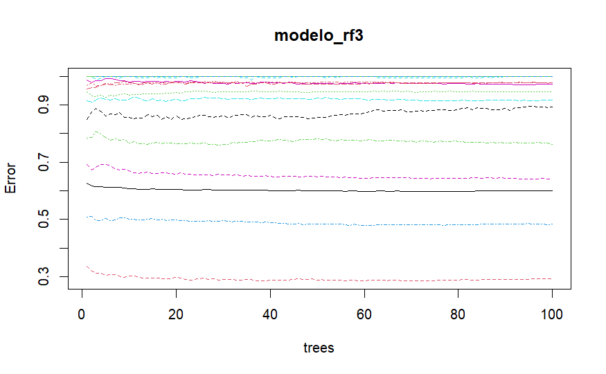

```r
plot(modelo_rf3)
```

### Se observa que este modelo falla en mas del 50% de las veces tiende mas a negar las predicciones que a establecerlas.

```r
predictions <- predict(modelo_rf3, newdata = test_data)
conf_matrix <- table(test_data$tipo_veh, predictions)
conf_matrix
```

```
    predictions
        1    2    3    5    6    7    8    9   10   11   12   13   14   16   17   18   20   21   22   23   24
  1  2380   55  642   25    5   10    0  114    2    0  106    1    7    0    0    1    0    0    0    0    0
  2   552   54  396   22    0    1    0   75    0    0   57    0    2    0    0    1    0    0    1    0    0
  3   892   64 1574   62    7   10    1  199    1    0  214    0    6    0    0    0    0    0    1    0    0
  5   335   16  344   72    3    0    0   43    0    0   39    0    4    0    0    0    0    0    1    0    0
  6   135    4   75   12    7    2    0    8    0    0    6    0    0    0    0    0    0    0    0    0    0
  7    78    4  109    0    0   38    0   28    0    0   76    0    1    0    0    0    0    0    0    0    0
  8    11    1    8    0    0    0    0    3    0    0    2    0    0    0    0    0    0    0    0    0    0
  9   252   12  396   24    0    3    0  259    0    0   87    0    4    0    0    0    0    0    0    0    0
  10   20    3    3    0    0    0    0    0    1    0    1    0    0    0    0    0    0    0    0    0    0
  11   71    3   48    0    0    2    0    7    0    0   11    0    1    0    0    0    0    0    0    0    0
  12  350   12  327   21    1    6    0   84    0    0  499    0    2    0    0    0    0    0    0    0    0
  13    4    0    9    2    0    0    0    0    0    0    0    0    0    0    0    0    0    0    0    0    0
  14  160   14  194    5    0    1    0   56    0    0   36    0    8    0    0    0    0    0    0    0    0
  16    1    0    2    0    0    0    0    0    0    0    0    0    0    0    0    0    0    0    0    0    0
  17   10    0    0    0    0    0    0    0    0    0    0    0    0    0    0    0    0    0    0    0    0
  18   38    1   24    1    0    0    0    3    0    0    1    0    0    0    0    0    0    0    0    0    0
  20    0    0    0    0    0    0    0    0    0    0    0    0    0    0    0    0    0    0    0    0    0
  21    0    0    3    0    0    0    0    0    0    0    0    0    0    0    0    0    0    0    0    0    0
  22   12    1   34    1    0    0    0    5    0    0    8    0    0    0    0    0    0    0    0    0    0
  23    0    0    0    0    0    0    0    0    0    0    0    0    0    0    0    0    0    0    0    0    0
  24    0    0    0    0    0    0    0    0    0    0    0    0    0    0    0    0    0    0    0    0    0
```

```r
accuracy <- sum(diag(conf_matrix)) / sum(conf_matrix)
accuracy
```

```
[1] 0.4026669
```

```r
# 5 escenarios distintos
escenarios <- data.frame(
  sexo_per  = factor(c(2, 1, 2, 1, 2), levels = levels(data_arbol3$sexo_per)),   # Mujer/Hombre
  horario  = factor(c(1, 2, 1, 1, 2), levels = levels(data_arbol3$horario)),   # Día, Noche
  mayor_menor  = factor(c(1, 2, 2, 1, 1), levels = levels(data_arbol3$mayor_menor)),   # Mayor,Menor
  tipo_eve  = factor(c(2, 5, 3, 1, 6), levels = levels(data_arbol3$tipo_eve)), # Choque, Atropello, Vuelco, Colisión, Derrape

  depto_ocu = factor(c(1, 6, 14, 18, 22), levels = levels(data_arbol3$depto_ocu)), # Guatemala, Santa Rosa, Quiché, Izabal, Jutiapa
  fall_les = factor(c(1, 1, 2, 2, 2), levels = levels(data_arbol3$fall_les)) # Guatemala, Santa Rosa, Quiché, Izabal, Jutiapa
)

predict(modelo_rf3, escenarios,type="prob")
```

```
     1    2    3    5    6    7 8    9 10 11   12 13   14 16 17   18 20 21 22 23 24
1 0.64 0.04 0.00 0.06 0.03 0.00 0 0.04  0  0 0.19  0 0.00  0  0 0.00  0  0  0  0  0
2 0.38 0.19 0.25 0.07 0.01 0.01 0 0.03  0  0 0.02  0 0.01  0  0 0.03  0  0  0  0  0
3 0.00 0.00 1.00 0.00 0.00 0.00 0 0.00  0  0 0.00  0 0.00  0  0 0.00  0  0  0  0  0
4 0.00 0.00 0.99 0.00 0.00 0.00 0 0.01  0  0 0.00  0 0.00  0  0 0.00  0  0  0  0  0
5 0.10 0.02 0.23 0.00 0.00 0.01 0 0.07  0  0 0.00  0 0.57  0  0 0.00  0  0  0  0  0
attr(,"class")
[1] "matrix" "array"  "votes"
```

```r
predict
```

```
function (object, ...)
UseMethod("predict")
<bytecode: 0x000002585be8c498>
<environment: namespace:stats>
```

## Modelo 4: Prediccion de jornada

```r
# Preparar datos y factores
data_arbol4$tipo_veh   <- factor(data_arbol4$tipo_veh)
data_arbol4$tipo_eve   <- factor(data_arbol4$tipo_eve)
data_arbol4$sexo_per   <- factor(data_arbol4$sexo_per)
data_arbol4$depto_ocu  <- factor(data_arbol4$depto_ocu)
data_arbol4$horario    <- factor(data_arbol4$horario)
data_arbol4$fall_les   <- factor(data_arbol4$fall_les)

# Entrenar RF
set.seed(123)

data <-  data_arbol4[sample(1:nrow(data_arbol4)), ]
train_index <- sample(1:nrow(data), 0.7 * nrow(data))
train_data <- data[train_index, ]
test_data <- data[-train_index, ]

modelo_rf4 <- randomForest(horario ~ tipo_eve + sexo_per + depto_ocu + tipo_veh + fall_les + mayor_menor,
                           data = train_data, ntree = 100, mtry = 4, importance = TRUE)
modelo_rf4
```

```
Call:
 randomForest(formula = horario ~ tipo_eve + sexo_per + depto_ocu +      tipo_veh + fall_les + mayor_menor, data = train_data, ntree = 100,      mtry = 4, importance = TRUE)
               Type of random forest: classification
                     Number of trees: 100
No. of variables tried at each split: 4

        OOB estimate of  error rate: 38.2%
Confusion matrix:
      1    2 class.error
1 25597 6717   0.2078666
2 14594 8884   0.6216032
```

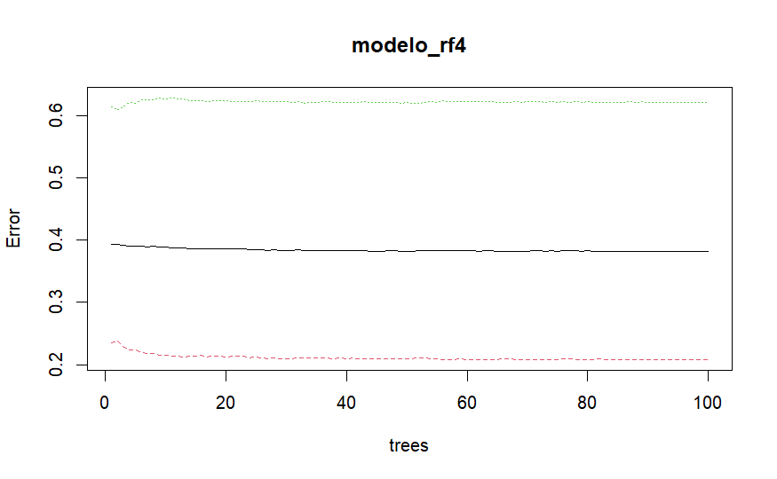

```r
plot(modelo_rf4)
```

```r
predictions <- predict(modelo_rf4, newdata = test_data)
conf_matrix <- table(test_data$horario, predictions)
conf_matrix
```

```
   predictions
        1     2
  1 10863  2848
  2  6397  3803
```

```r
accuracy <- sum(diag(conf_matrix)) / sum(conf_matrix)
accuracy
```

```
[1] 0.6133579
```

```r
escenarios <- data.frame(
  sexo_per  = factor(c(2, 1, 2, 1, 2), levels = levels(data_arbol4$sexo_per)),   # Mujer/Hombre
  mayor_menor  = factor(c(1, 2, 2, 1, 1), levels = levels(data_arbol4$mayor_menor)),   # Mayor,Menor
  tipo_eve  = factor(c(2, 5, 3, 1, 6), levels = levels(data_arbol4$tipo_eve)), # Choque, Atropello, Vuelco, Colisión, Derrape
  tipo_veh  = factor(c(4, 1, 3, 2, 5), levels = levels(data_arbol4$tipo_veh)),   # Motocicleta, Automóvil, Pick up, Camioneta sport, Camión
  depto_ocu = factor(c(1, 6, 14, 18, 22), levels = levels(data_arbol4$depto_ocu)), # Guatemala, Santa Rosa, Quiché, Izabal, Jutiapa
  fall_les = factor(c(1, 1, 2, 2, 2), levels = levels(data_arbol4$fall_les)) # Fallecido, Lesionado
)
predict(modelo_rf4, escenarios,type="prob")
```

```
     1    2
1 0.15 0.85
2 0.60 0.40
3 0.93 0.07
4 0.70 0.30
5 0.42 0.58
attr(,"class")
[1] "matrix" "array"  "votes"
```

```r
predict
```

```
function (object, ...)
UseMethod("predict")
<bytecode: 0x000002585be8c498>
<environment: namespace:stats>
```

## Modelo 5: Prediccion de sexo

```r
data_rf5 <- datos_consolidados %>%
  filter(fall_les %in% c(1, 2), sexo_per != 9, tipo_eve != 99, tipo_veh != 99, edad_per != 999)

data_rf5$sexo_per <- factor(data_rf5$sexo_per)
data_rf5$tipo_eve <- factor(data_rf5$tipo_eve)
data_rf5$tipo_veh <- factor(data_rf5$tipo_veh)
data_rf5$depto_ocu <- factor(data_rf5$depto_ocu)
data_rf5$horario <- factor(data_rf5$horario)
data_rf5$fall_les <- factor(data_rf5$fall_les)
data_rf5$mayor_menor <- factor(data_rf5$mayor_menor)

# Entrenar RF
set.seed(123)
data <-  data_rf5[sample(1:nrow(data_rf5)), ]
train_index <- sample(1:nrow(data), 0.7 * nrow(data))
train_data <- data[train_index, ]
test_data <- data[-train_index, ]
modelo_rf5 <- randomForest(sexo_per ~ tipo_veh + depto_ocu + fall_les + horario + tipo_eve + mayor_menor,
                           data = train_data, ntree = 50, mtry = 3, importance = TRUE)


modelo_rf5
```

```
Call:
 randomForest(formula = sexo_per ~ tipo_veh + depto_ocu + fall_les +      horario + tipo_eve + mayor_menor, data = train_data, ntree = 50,      mtry = 3, importance = TRUE)
               Type of random forest: classification
                     Number of trees: 50
No. of variables tried at each split: 3

        OOB estimate of  error rate: 28.95%
Confusion matrix:
      1    2 class.error
1 36954 2868  0.07202049
2 13285 2685  0.83187226
```

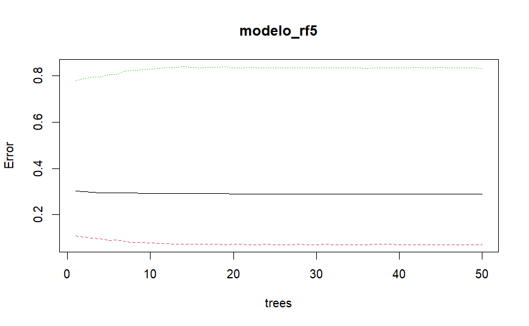

```r
plot(modelo_rf5)
```

```r
predictions <- predict(modelo_rf5, newdata = test_data)
conf_matrix <- table(test_data$sexo_per, predictions)
conf_matrix
```

```
   predictions
        1     2
  1 15986  1162
  2  5691  1072
```

```r
accuracy <- sum(diag(conf_matrix)) / sum(conf_matrix)
accuracy
```

```
[1] 0.7133955
```

```r
escenarios <- data.frame(
  horario  = factor(c(1, 2, 1, 1, 2), levels = levels(data_rf5$horario)),   # Día, Noche
  mayor_menor  = factor(c(1, 2, 2, 1, 1), levels = levels(data_rf5$mayor_menor)),   # Mayor,Menor
  tipo_eve  = factor(c(2, 5, 3, 1, 6), levels = levels(data_rf5$tipo_eve)), # Choque, Atropello, Vuelco, Colisión, Derrape
  tipo_veh  = factor(c(4, 1, 3, 2, 5), levels = levels(data_rf5$tipo_veh)),   # Motocicleta, Automóvil, Pick up, Camioneta sport, Camión
  depto_ocu = factor(c(1, 6, 14, 18, 22), levels = levels(data_rf5$depto_ocu)), # Guatemala, Santa Rosa, Quiché, Izabal, Jutiapa
  fall_les = factor(c(1, 1, 2, 2, 2), levels = levels(data_rf5$fall_les)) # Fallecido, Lesionado
)

predict(modelo_rf5, escenarios,type="prob")
```

```
     1    2
1 1.00 0.00
2 0.42 0.58
3 0.84 0.16
4 0.72 0.28
5 0.86 0.14
attr(,"class")
[1] "matrix" "array"  "votes"
```

```r
predict
```

```
function (object, ...)
UseMethod("predict")
<bytecode: 0x000002585be8c498>
<environment: namespace:stats>
```

#Modelo 6: Prediccion si es mayor o menor

```r
data_rf6 <- datos_consolidados %>%
  filter(fall_les %in% c(1, 2), sexo_per != 9, tipo_eve != 99, tipo_veh != 99, edad_per != 999)

data_rf6$sexo_per <- factor(data_rf6$sexo_per)
data_rf6$tipo_eve <- factor(data_rf6$tipo_eve)
data_rf6$tipo_veh <- factor(data_rf6$tipo_veh)
data_rf6$depto_ocu <- factor(data_rf6$depto_ocu)
data_rf6$horario <- factor(data_rf6$horario)
data_rf6$fall_les <- factor(data_rf6$fall_les)
data_rf6$g_hora_5 <- factor(data_rf6$g_hora_5)
data_rf6$mayor_menor <- factor(data_rf6$mayor_menor)

# Entrenar RF
set.seed(123)
data <-  data_rf6[sample(1:nrow(data_rf6)), ]
train_index <- sample(1:nrow(data), 0.7 * nrow(data))
train_data <- data[train_index, ]
test_data <- data[-train_index, ]
modelo_rf6 <- randomForest(mayor_menor ~ tipo_veh + depto_ocu + fall_les + horario + tipo_eve + sexo_per,
                           data = train_data, ntree = 50, mtry = 3, importance = TRUE)


modelo_rf6
```

```
Call:
 randomForest(formula = mayor_menor ~ tipo_veh + depto_ocu + fall_les +      horario + tipo_eve + sexo_per, data = train_data, ntree = 50,      mtry = 3, importance = TRUE)
               Type of random forest: classification
                     Number of trees: 50
No. of variables tried at each split: 3

        OOB estimate of  error rate: 15.72%
Confusion matrix:
      1   2 9 class.error
1 46850 338 0 0.007162838
2  8412 174 0 0.979734451
9    18   0 0 1.000000000
```

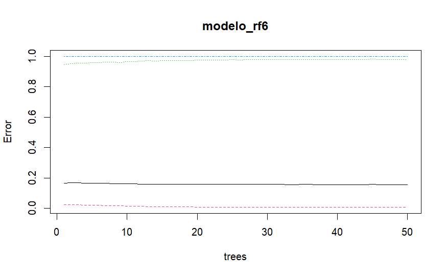

```r
plot(modelo_rf6)
```

```r
predictions <- predict(modelo_rf6, newdata = test_data)
conf_matrix <- table(test_data$mayor_menor, predictions)
conf_matrix
```

```
   predictions
        1     2     9
  1 20119   118     0
  2  3599    67     0
  9     8     0     0
```

```r
accuracy <- sum(diag(conf_matrix)) / sum(conf_matrix)
accuracy
```

```
[1] 0.844214
```

```r
escenarios <- data.frame(
  sexo_per  = factor(c(2, 1, 2, 1, 2), levels = levels(data_rf6$sexo_per)),   # Mujer/Hombre
  horario  = factor(c(1, 2, 1, 1, 2), levels = levels(data_rf6$horario)),   # Día, Noche

  tipo_eve  = factor(c(2, 5, 3, 1, 6), levels = levels(data_rf6$tipo_eve)), # Choque, Atropello, Vuelco, Colisión, Derrape
  tipo_veh  = factor(c(4, 1, 3, 2, 5), levels = levels(data_rf6$tipo_veh)),   # Motocicleta, Automóvil, Pick up, Camioneta sport, Camión
  depto_ocu = factor(c(1, 6, 14, 18, 22), levels = levels(data_rf6$depto_ocu)), # Guatemala, Santa Rosa, Quiché, Izabal, Jutiapa
  fall_les = factor(c(1, 1, 2, 2, 2), levels = levels(data_rf6$fall_les)) # Fallecido, Lesionado
)
predict(modelo_rf6, escenarios,type="prob")
```

```
     1    2 9
1 1.00 0.00 0
2 1.00 0.00 0
3 0.96 0.04 0
4 0.96 0.04 0
5 0.96 0.04 0
attr(,"class")
[1] "matrix" "array"  "votes"
```

```r
predict
```

```
function (object, ...)
UseMethod("predict")
<bytecode: 0x000002585be8c498>
<environment: namespace:stats>
```

```r
install.packages("writexl")   # Ejecuta solo una vez
library(writexl)

# Si quieres preservar etiquetas de factores:
df_export_xlsx <- datos_consolidados %>% dplyr::mutate(dplyr::across(where(is.factor), as.character))

# Exportar a Excel
write_xlsx(df_export_xlsx, path = "datos_consolidados.xlsx")
```